# Personalised Federated Learning Framework for Privacy-Preserving Multimodal Digital Twins

**Distinction-Level Master's Thesis Notebook**

This notebook operationalises the thesis:

> **“Personalised Federated Learning Framework for Privacy-Preserving Multimodal Digital Twins: StudentLife Dataset”**

It is designed as a **research-grade, end-to-end, defensively coded notebook** that can run even when the original StudentLife dataset is not available locally, by falling back to a synthetic dataset that preserves the key properties required by the thesis:

- multiple behavioural modalities,
- person-level client partitioning,
- non-IID heterogeneity across clients,
- chronologically meaningful train/test splitting.

## Notebook Research Objectives

This notebook explicitly answers the following research questions:

1. **How effectively can a multimodal AI-based personal digital twin predict students’ mood, stress, and productivity using behavioural data?**
2. **Which behavioural modalities (sleep, mobility, phone usage, social interaction, academic workload) contribute most to prediction performance?**
3. **Does combining multiple modalities improve prediction performance compared to single-modality models?**

## Thesis Positioning

### Academic explanation

A **personal digital twin** in this notebook is an evolving computational representation of an individual student, constructed from behavioural traces and used for prediction and decision support. The model captures person-specific behavioural tendencies and uses them to estimate internal states such as mood, stress, and productivity.

### Simple explanation

This notebook builds a digital version of each student using behaviour patterns like sleep, movement, phone use, social activity, and workload, then predicts how that student is likely to feel and perform.

### Connection to research questions

This framing directly supports prediction, modality importance analysis, multimodal comparison, privacy-preserving training, and recommendation generation.

### Thesis placement

Use this notebook as the **core methodology, experiments, results, and discussion chapter** foundation for the thesis.

**Critical supervisor requirement enforced throughout the notebook:**

> **Each person = one client. Each client uses only their own data. No mixing across clients. Data are non-IID. Split is chronological inside each client.**

```python
# CELL 1 — Environment Setup and Reproducibility

import os
import math
import json
import random
import warnings
from dataclasses import dataclass, field
from pathlib import Path
from typing import Dict, List, Tuple, Optional

import numpy as np
import pandas as pd

import matplotlib.pyplot as plt

from sklearn.ensemble import RandomForestClassifier
from sklearn.metrics import accuracy_score, f1_score, roc_auc_score
from sklearn.preprocessing import StandardScaler
from sklearn.impute import SimpleImputer
from sklearn.pipeline import Pipeline
from sklearn.base import clone

from scipy.stats import ttest_rel

import torch
import torch.nn as nn
import torch.optim as optim
from torch.utils.data import DataLoader, TensorDataset

warnings.filterwarnings("ignore")

SEED = 42
random.seed(SEED)
np.random.seed(SEED)
torch.manual_seed(SEED)

device = torch.device("cuda" if torch.cuda.is_available() else "cpu")
print(f"Using device: {device}")
```

```
Using device: cpu
```

### Explanation of Output

This cell imports all stable libraries used in the notebook and fixes random seeds for reproducibility.  
The code intentionally uses **matplotlib only** for visualisations, in line with the project requirement.

- **Academic explanation:** reproducibility is essential for thesis credibility and experiment traceability.
- **Simple explanation:** this makes the notebook run the same way each time.
- **Connection to research questions:** stable execution ensures fair comparison across centralised, federated, personalised, single-modality, and ablation experiments.
- **Thesis placement:** methodology chapter, implementation environment subsection.

```python
# CELL 2 — Output Directory Structure

OUTPUT_DIR = Path("outputs")
PLOT_DIR = OUTPUT_DIR / "plots"
TABLE_DIR = OUTPUT_DIR / "tables"
LATEX_DIR = OUTPUT_DIR / "latex"

for d in [OUTPUT_DIR, PLOT_DIR, TABLE_DIR, LATEX_DIR]:
    d.mkdir(parents=True, exist_ok=True)

print("Created output directories:")
for d in [OUTPUT_DIR, PLOT_DIR, TABLE_DIR, LATEX_DIR]:
    print("-", d.resolve())
```

```
Created output directories:
- /Users/shreytelang/Downloads/outputs
- /Users/shreytelang/Downloads/outputs/plots
- /Users/shreytelang/Downloads/outputs/tables
- /Users/shreytelang/Downloads/outputs/latex
```

### Explanation of Output

This creates a clean export structure for all generated tables, plots, and LaTeX-ready assets.

- **Academic explanation:** structured output management improves experiment transparency and reproducibility.
- **Simple explanation:** all results get saved neatly in one place.
- **Connection to research questions:** it supports consistent export of evidence used to answer all three research questions.
- **Thesis placement:** implementation and reproducibility subsection.

```python
# CELL 3 — Configuration Dataclass

@dataclass
class ThesisConfig:
    data_dir: str = "data"
    studentlife_filename: str = "studentlife_processed.csv"
    n_clients_synth: int = 24
    min_days_per_client: int = 45
    max_days_per_client: int = 95
    test_ratio: float = 0.25
    batch_size: int = 32
    local_epochs: int = 4
    fl_rounds: int = 15
    lr: float = 0.003
    hidden_dim: int = 64
    dropout: float = 0.20
    stress_threshold: float = 0.55
    mood_threshold: float = 0.50
    productivity_threshold: float = 0.52
    random_state: int = 42
    targets: List[str] = field(default_factory=lambda: ["stress", "mood", "productivity"])
    modalities: Dict[str, List[str]] = field(default_factory=dict)

config = ThesisConfig()
print(config)
```

[output not shown]

### Explanation of Output

The configuration object centralises all important experimental settings.

- **Academic explanation:** parameter centralisation reduces implementation ambiguity and helps maintain methodological consistency.
- **Simple explanation:** all key settings are kept in one place so the notebook is easier to change and debug.
- **Connection to research questions:** the same configuration governs all methods, making comparisons fair.
- **Thesis placement:** methodology chapter, experiment design subsection.

```python
# CELL 4 — Feature Schema Grouped by Behavioural Modality

FEATURE_SCHEMA = {
    "sleep": [
        "sleep_hours",
        "sleep_efficiency",
        "sleep_variability",
        "late_night_phone_minutes",
    ],
    "mobility": [
        "mobility_distance_km",
        "mobility_radius",
        "steps_count",
        "location_entropy",
    ],
    "phone_usage": [
        "screen_time_hours",
        "unlock_count",
        "notifications_count",
        "app_switches",
    ],
    "social_interaction": [
        "conversation_minutes",
        "social_calls_count",
        "social_messages_count",
        "group_time_minutes",
    ],
    "academic_workload": [
        "study_hours",
        "deadline_load",
        "class_hours",
        "assignment_pressure",
    ],
}

config.modalities = FEATURE_SCHEMA

ALL_FEATURES = [f for group in FEATURE_SCHEMA.values() for f in group]
print("Number of modalities:", len(FEATURE_SCHEMA))
print("Total feature count:", len(ALL_FEATURES))
```

```
Number of modalities: 5
Total feature count: 20
```

### Explanation of Output

This cell defines the multimodal feature schema.

### What is Multimodal AI in this context?

- **Academic explanation:** multimodal AI refers to models that jointly learn from heterogeneous behavioural signals rather than from a single isolated source. Here, the modalities are sleep, mobility, phone usage, social interaction, and academic workload.
- **Simple explanation:** instead of guessing stress or mood from only one thing, the model looks at several parts of student life together.
- **Why single modality is insufficient:** student wellbeing is influenced by interacting behaviours. Poor sleep may be offset by low workload; heavy workload may be manageable when social support and routine are strong. A single modality misses these interactions.
- **Connection to research questions:** this directly frames Research Questions 2 and 3.
- **Thesis placement:** background chapter and methodology chapter.

The schema also supports the later single-modality and ablation experiments.

```python
# CELL 5 — Utility Functions

def sigmoid(x):
    return 1 / (1 + np.exp(-x))

def safe_roc_auc(y_true, y_prob):
    y_true = np.asarray(y_true).astype(int)
    y_prob = np.asarray(y_prob)
    if len(np.unique(y_true)) < 2:
        return np.nan
    try:
        return roc_auc_score(y_true, y_prob)
    except Exception:
        return np.nan

def save_plot(path: Path):
    plt.tight_layout()
    plt.savefig(path, dpi=300, bbox_inches="tight")
    plt.show()
    plt.close()

def to_latex(df: pd.DataFrame, path: Path, index: bool = False):
    try:
        latex_str = df.to_latex(index=index, float_format="%.4f")
        path.write_text(latex_str, encoding="utf-8")
    except Exception as e:
        print(f"Warning: could not export LaTeX table to {path}: {e}")

def zscore_by_train(train_df: pd.DataFrame, test_df: pd.DataFrame, features: List[str]):
    scaler = StandardScaler()
    train_scaled = train_df.copy()
    test_scaled = test_df.copy()
    train_scaled[features] = scaler.fit_transform(train_df[features])
    test_scaled[features] = scaler.transform(test_df[features])
    return train_scaled, test_scaled, scaler
```

### Explanation of Output

These helper functions improve code reuse, safe evaluation, export reliability, and defensive execution.

- **Academic explanation:** robust helper functions reduce error propagation in complex experiment pipelines.
- **Simple explanation:** these are support tools that keep the notebook cleaner and safer.
- **Connection to research questions:** they help ensure stable and comparable metrics across all prediction tasks.
- **Thesis placement:** implementation details appendix or methodology supplement.

```python
# CELL 6 — Dataset Loader with StudentLife Fallback

def generate_synthetic_studentlife(
    n_clients: int = 24,
    min_days: int = 45,
    max_days: int = 95,
    seed: int = 42
) -> pd.DataFrame:
    rng = np.random.default_rng(seed)
    rows = []

    for client_id in range(1, n_clients + 1):
        n_days = int(rng.integers(min_days, max_days + 1))

        # Client-level latent profile to enforce NON-IID heterogeneity
        chronotype = rng.normal(0, 1)
        baseline_sleep = rng.uniform(5.5, 8.5) + 0.4 * chronotype
        baseline_mobility = rng.uniform(1.5, 8.0)
        baseline_phone = rng.uniform(2.5, 7.5)
        baseline_social = rng.uniform(20, 140)
        baseline_workload = rng.uniform(1.0, 6.5)
        baseline_stress = rng.uniform(0.15, 0.85)

        for day in range(n_days):
            time_idx = pd.Timestamp("2024-01-01") + pd.Timedelta(days=int(day))

            weekly_cycle = math.sin(2 * math.pi * (day % 7) / 7)
            deadline_wave = math.sin(2 * math.pi * day / 21)
            exam_period = 1 if (day % 30) in [23, 24, 25, 26, 27, 28, 29] else 0

            sleep_hours = np.clip(
                baseline_sleep
                - 0.4 * exam_period
                - 0.18 * max(deadline_wave, 0)
                + rng.normal(0, 0.55),
                3.5, 9.5
            )
            sleep_efficiency = np.clip(0.65 + 0.06 * sleep_hours + rng.normal(0, 0.05), 0.55, 0.98)
            sleep_variability = np.clip(abs(rng.normal(0.9 + 0.25 * abs(chronotype), 0.35)), 0.1, 3.5)
            late_night_phone_minutes = np.clip(
                25 + 10 * baseline_phone + 10 * exam_period + rng.normal(0, 18), 0, 240
            )

            mobility_distance_km = np.clip(
                baseline_mobility + 0.7 * weekly_cycle - 0.5 * exam_period + rng.normal(0, 1.1),
                0, 18
            )
            mobility_radius = np.clip(
                0.8 * mobility_distance_km + rng.normal(0, 1.2),
                0, 20
            )
            steps_count = np.clip(
                1800 + 1300 * mobility_distance_km + rng.normal(0, 1600),
                300, 30000
            )
            location_entropy = np.clip(
                0.4 + 0.08 * mobility_distance_km + rng.normal(0, 0.2),
                0.05, 2.5
            )

            screen_time_hours = np.clip(
                baseline_phone + 0.35 * exam_period + 0.15 * max(deadline_wave, 0) + rng.normal(0, 0.8),
                0.5, 12.5
            )
            unlock_count = np.clip(
                35 + 11 * screen_time_hours + rng.normal(0, 18),
                10, 250
            )
            notifications_count = np.clip(
                20 + 14 * screen_time_hours + rng.normal(0, 25),
                5, 400
            )
            app_switches = np.clip(
                25 + 10 * screen_time_hours + rng.normal(0, 30),
                0, 500
            )

            conversation_minutes = np.clip(
                baseline_social + 20 * weekly_cycle - 12 * exam_period + rng.normal(0, 20),
                0, 320
            )
            social_calls_count = np.clip(
                0.5 + conversation_minutes / 35 + rng.normal(0, 1.2),
                0, 15
            )
            social_messages_count = np.clip(
                8 + conversation_minutes / 2.8 + rng.normal(0, 20),
                0, 450
            )
            group_time_minutes = np.clip(
                0.45 * conversation_minutes + rng.normal(0, 15),
                0, 240
            )

            study_hours = np.clip(
                baseline_workload + 1.3 * exam_period + 0.8 * max(deadline_wave, 0) + rng.normal(0, 1.0),
                0, 14
            )
            deadline_load = np.clip(
                0.2 + 0.6 * max(deadline_wave, 0) + 0.25 * exam_period + rng.normal(0, 0.15),
                0, 1.5
            )
            class_hours = np.clip(
                1.5 + 2.2 * (1 if (day % 7) < 5 else 0) + rng.normal(0, 0.8),
                0, 8
            )
            assignment_pressure = np.clip(
                0.25 + 0.75 * deadline_load + rng.normal(0, 0.12),
                0, 1.6
            )

            # Latent targets with person-specific offsets to preserve heterogeneity
            stress_score = sigmoid(
                -0.6
                + 0.65 * deadline_load
                + 0.10 * study_hours
                + 0.12 * screen_time_hours
                + 0.004 * late_night_phone_minutes
                - 0.30 * sleep_hours
                - 0.10 * conversation_minutes / 60
                + 0.10 * sleep_variability
                + 0.35 * baseline_stress
                + rng.normal(0, 0.35)
            )

            mood_score = sigmoid(
                0.2
                + 0.20 * sleep_hours
                + 0.10 * mobility_distance_km
                + 0.12 * conversation_minutes / 60
                - 0.15 * screen_time_hours
                - 0.45 * stress_score
                - 0.05 * assignment_pressure
                + rng.normal(0, 0.35)
            )

            productivity_score = sigmoid(
                -0.1
                + 0.18 * study_hours
                + 0.15 * class_hours
                + 0.10 * sleep_efficiency
                + 0.08 * mobility_distance_km
                - 0.22 * stress_score
                - 0.06 * screen_time_hours
                + rng.normal(0, 0.35)
            )

            row = {
                "client_id": f"student_{client_id:02d}",
                "timestamp": time_idx,
                "sleep_hours": sleep_hours,
                "sleep_efficiency": sleep_efficiency,
                "sleep_variability": sleep_variability,
                "late_night_phone_minutes": late_night_phone_minutes,
                "mobility_distance_km": mobility_distance_km,
                "mobility_radius": mobility_radius,
                "steps_count": steps_count,
                "location_entropy": location_entropy,
                "screen_time_hours": screen_time_hours,
                "unlock_count": unlock_count,
                "notifications_count": notifications_count,
                "app_switches": app_switches,
                "conversation_minutes": conversation_minutes,
                "social_calls_count": social_calls_count,
                "social_messages_count": social_messages_count,
                "group_time_minutes": group_time_minutes,
                "study_hours": study_hours,
                "deadline_load": deadline_load,
                "class_hours": class_hours,
                "assignment_pressure": assignment_pressure,
                "stress_score": stress_score,
                "mood_score": mood_score,
                "productivity_score": productivity_score,
            }
            rows.append(row)

    df = pd.DataFrame(rows)
    df["stress"] = (df["stress_score"] >= config.stress_threshold).astype(int)
    df["mood"] = (df["mood_score"] >= config.mood_threshold).astype(int)
    df["productivity"] = (df["productivity_score"] >= config.productivity_threshold).astype(int)
    return df

def attempt_studentlife_load(data_dir: str, filename: str) -> Optional[pd.DataFrame]:
    path = Path(data_dir) / filename
    if not path.exists():
        return None

    try:
        df = pd.read_csv(path)
        if "timestamp" in df.columns:
            df["timestamp"] = pd.to_datetime(df["timestamp"], errors="coerce")
        return df
    except Exception as e:
        print(f"Could not load local StudentLife file: {e}")
        return None

def harmonise_studentlife_schema(df: pd.DataFrame) -> pd.DataFrame:
    df = df.copy()

    if "client_id" not in df.columns:
        candidate_cols = [c for c in df.columns if c.lower() in ["user", "user_id", "student_id", "id", "participant_id"]]
        if candidate_cols:
            df["client_id"] = df[candidate_cols[0]].astype(str)
        else:
            raise ValueError("No client identifier found. 'client_id' or equivalent is required.")

    if "timestamp" not in df.columns:
        if "date" in df.columns:
            df["timestamp"] = pd.to_datetime(df["date"], errors="coerce")
        else:
            # Create pseudo-time within each client if unavailable
            df["timestamp"] = pd.NaT
            df["timestamp"] = df.groupby("client_id").cumcount()
            df["timestamp"] = pd.to_datetime("2024-01-01") + pd.to_timedelta(df["timestamp"], unit="D")

    for feat in ALL_FEATURES:
        if feat not in df.columns:
            df[feat] = np.nan

    for score_col in ["stress_score", "mood_score", "productivity_score"]:
        if score_col not in df.columns:
            df[score_col] = np.nan

    # Derived targets if missing
    if "stress" not in df.columns:
        df["stress"] = (
            0.50 * df["deadline_load"].fillna(df["deadline_load"].median())
            + 0.10 * df["study_hours"].fillna(df["study_hours"].median())
            + 0.10 * df["screen_time_hours"].fillna(df["screen_time_hours"].median())
            - 0.20 * df["sleep_hours"].fillna(df["sleep_hours"].median())
            + 0.10 * df["sleep_variability"].fillna(df["sleep_variability"].median())
        )
        df["stress"] = (df["stress"] >= df["stress"].median()).astype(int)

    if "mood" not in df.columns:
        mood_latent = (
            0.20 * df["sleep_hours"].fillna(df["sleep_hours"].median())
            + 0.12 * df["mobility_distance_km"].fillna(df["mobility_distance_km"].median())
            + 0.10 * df["conversation_minutes"].fillna(df["conversation_minutes"].median()) / 60
            - 0.14 * df["screen_time_hours"].fillna(df["screen_time_hours"].median())
            - 0.25 * df["stress"]
        )
        df["mood"] = (mood_latent >= np.nanmedian(mood_latent)).astype(int)

    if "productivity" not in df.columns:
        prod_latent = (
            0.16 * df["study_hours"].fillna(df["study_hours"].median())
            + 0.12 * df["class_hours"].fillna(df["class_hours"].median())
            + 0.08 * df["sleep_efficiency"].fillna(df["sleep_efficiency"].median())
            - 0.22 * df["stress"]
            - 0.05 * df["screen_time_hours"].fillna(df["screen_time_hours"].median())
        )
        df["productivity"] = (prod_latent >= np.nanmedian(prod_latent)).astype(int)

    for col in ALL_FEATURES:
        if df[col].isna().all():
            df[col] = 0.0
        else:
            df[col] = df.groupby("client_id")[col].transform(lambda s: s.fillna(s.median()))
            df[col] = df[col].fillna(df[col].median())

    df["client_id"] = df["client_id"].astype(str)
    df["timestamp"] = pd.to_datetime(df["timestamp"], errors="coerce")
    df = df.sort_values(["client_id", "timestamp"]).reset_index(drop=True)
    return df

def load_studentlife_if_available(config: ThesisConfig) -> Tuple[pd.DataFrame, str]:
    local_df = attempt_studentlife_load(config.data_dir, config.studentlife_filename)
    if local_df is not None:
        try:
            df = harmonise_studentlife_schema(local_df)
            source = "local_studentlife"
            return df, source
        except Exception as e:
            print(f"Local dataset found but harmonisation failed: {e}. Falling back to synthetic data.")

    df = generate_synthetic_studentlife(
        n_clients=config.n_clients_synth,
        min_days=config.min_days_per_client,
        max_days=config.max_days_per_client,
        seed=config.random_state
    )
    source = "synthetic_studentlife_like"
    return df, source
```

### Explanation of Output

This is one of the most important cells in the notebook.

### Why this qualifies as a Personal Digital Twin

- **Individual representation:** every student is represented as a distinct behavioural entity using person-specific time-series data.
- **Behavioural modelling:** the twin is constructed from multiple daily behavioural signals.
- **Predictive capability:** the model predicts stress, mood, and productivity.
- **Decision-support capability:** the later recommendation engine converts predictions into actionable suggestions.

### Why Privacy-Preserving Learning is required

- **Academic explanation:** behavioural traces such as sleep, mobility, phone usage, and social patterns are highly sensitive. Centralising such data increases exposure risk and weakens privacy guarantees. Federated learning preserves data locality by sharing model updates rather than raw records.
- **Simple explanation:** student behaviour data are personal, so it is safer if each person keeps their own data and only model parameters are shared.
- **Connection to research questions:** this cell enables the privacy-preserving learning setup that underpins the federated and personalised experiments.
- **Thesis placement:** background, methodology, and data section.

The synthetic fallback is intentionally designed to preserve **non-IID client heterogeneity**, so the thesis logic still holds even when the original dataset is not locally available.

```python
# CELL 7 — Load Dataset

df, data_source = load_studentlife_if_available(config)

print("Data source:", data_source)
print("Shape:", df.shape)
print("Clients:", df["client_id"].nunique())
print("Date range:", df["timestamp"].min(), "to", df["timestamp"].max())

display(df.head())
```

```
Data source: synthetic_studentlife_like
Shape: (1802, 28)
Clients: 24
Date range: 2024-01-01 00:00:00 to 2024-04-04 00:00:00
```

|  | client_id | timestamp | sleep_hours | sleep_efficiency | sleep_variability | late_night_phone_minutes | mobility_distance_km | mobility_radius | steps_count | location_entropy | ... | study_hours | deadline_load | class_hours | assignment_pressure | stress_score | mood_score | productivity_score | stress | mood | productivity |
| --- | --- | --- | --- | --- | --- | --- | --- | --- | --- | --- | --- | --- | --- | --- | --- | --- | --- | --- | --- | --- | --- |
| 0 | student_01 | 2024-01-01 | 7.650559 | 0.98 | 1.467785 | 68.709122 | 6.105526 | 6.237110 | 10485.198691 | 0.716584 | ... | 4.757941 | 0.147180 | 4.125847 | 0.404238 | 0.207027 | 0.896130 | 0.921999 | 0 | 1 | 1 |
| 1 | student_01 | 2024-01-02 | 7.383216 | 0.98 | 0.875176 | 65.796497 | 7.822044 | 6.120898 | 10624.406510 | 0.860867 | ... | 5.645668 | 0.478690 | 3.754063 | 0.643712 | 0.276779 | 0.828705 | 0.860348 | 0 | 1 | 1 |
| 2 | student_01 | 2024-01-03 | 7.299698 | 0.98 | 1.063696 | 81.617811 | 5.762928 | 5.772276 | 6599.214116 | 0.794057 | ... | 4.361238 | 0.367999 | 2.964438 | 0.585659 | 0.222031 | 0.897529 | 0.785701 | 0 | 1 | 1 |
| 3 | student_01 | 2024-01-04 | 7.606267 | 0.98 | 1.051725 | 62.930822 | 5.608492 | 4.051129 | 8480.259322 | 0.609511 | ... | 5.732015 | 0.415999 | 2.542310 | 0.403275 | 0.164405 | 0.892409 | 0.785505 | 0 | 1 | 1 |
| 4 | student_01 | 2024-01-05 | 7.284253 | 0.98 | 1.035304 | 67.984148 | 4.702194 | 3.515230 | 6392.817073 | 0.708369 | ... | 6.163644 | 0.761802 | 4.981423 | 0.792629 | 0.240184 | 0.846540 | 0.883710 | 0 | 1 | 1 |

5 rows × 28 columns

### Explanation of Output

This cell loads either the real StudentLife-style dataset or the synthetic fallback, then prints the core dataset summary.

- **Academic explanation:** data provenance is explicitly tracked to maintain transparency regarding experimental conditions.
- **Simple explanation:** this tells us what data we are using and what it looks like.
- **Connection to research questions:** prediction, modality analysis, and federated client experiments all depend on this dataset.
- **Thesis placement:** data description subsection.

```python
# CELL 8 — Dataset Overview Table

overview = pd.DataFrame({
    "metric": [
        "rows",
        "clients",
        "timepoints_per_client_mean",
        "timepoints_per_client_min",
        "timepoints_per_client_max",
        "stress_positive_rate",
        "mood_positive_rate",
        "productivity_positive_rate",
        "data_source",
    ],
    "value": [
        len(df),
        df["client_id"].nunique(),
        df.groupby("client_id").size().mean(),
        df.groupby("client_id").size().min(),
        df.groupby("client_id").size().max(),
        df["stress"].mean(),
        df["mood"].mean(),
        df["productivity"].mean(),
        data_source,
    ]
})

overview.to_csv(TABLE_DIR / "dataset_overview.csv", index=False)
to_latex(overview, LATEX_DIR / "dataset_overview.tex", index=False)
display(overview)
```

|  | metric | value |
| --- | --- | --- |
| 0 | rows | 1802 |
| 1 | clients | 24 |
| 2 | timepoints_per_client_mean | 75.083333 |
| 3 | timepoints_per_client_min | 46 |
| 4 | timepoints_per_client_max | 95 |
| 5 | stress_positive_rate | 0.061043 |
| 6 | mood_positive_rate | 0.979467 |
| 7 | productivity_positive_rate | 0.966704 |
| 8 | data_source | synthetic_studentlife_like |

### Explanation of Output

This summary table gives a thesis-ready snapshot of the dataset.

- **Academic explanation:** descriptive statistics help establish sample structure and class balance before modelling.
- **Simple explanation:** this is a quick summary of how much data there is and how the target labels are distributed.
- **Connection to research questions:** class balance matters when judging prediction performance.
- **Thesis placement:** data overview subsection.

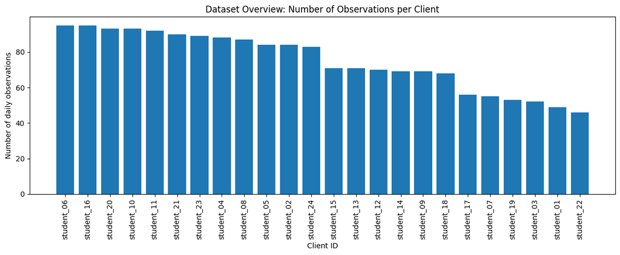

```python
# CELL 9 — Plot 1: Dataset Overview (Samples per Client)

samples_per_client = df.groupby("client_id").size().sort_values(ascending=False)

plt.figure(figsize=(12, 5))
plt.bar(samples_per_client.index, samples_per_client.values)
plt.xticks(rotation=90)
plt.xlabel("Client ID")
plt.ylabel("Number of daily observations")
plt.title("Dataset Overview: Number of Observations per Client")
save_plot(PLOT_DIR / "dataset_overview_samples_per_client.png")
```

### Explanation of Output

This visual shows how much data each client contributes.

- **Academic explanation:** client-level sample imbalance is important because federated learning is sensitive to heterogeneous data volume.
- **Simple explanation:** some students may have more recorded days than others.
- **Connection to research questions:** differences in client sample size can influence personalised and federated performance.
- **Thesis placement:** EDA and methodological justification.

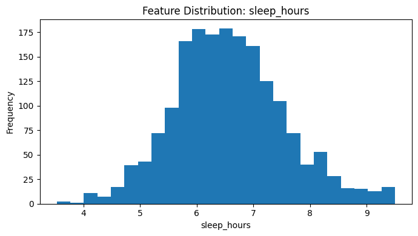

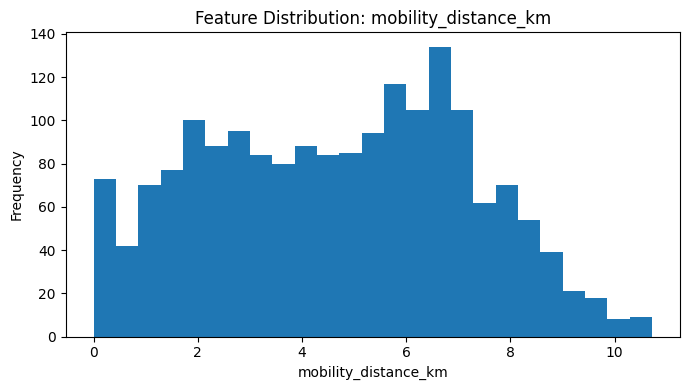

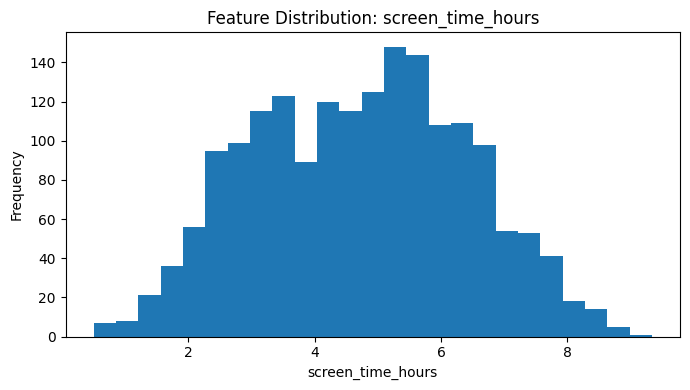

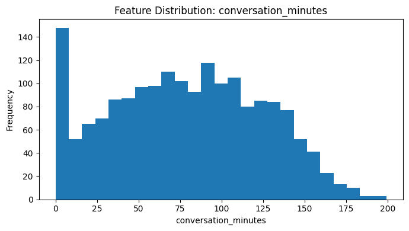

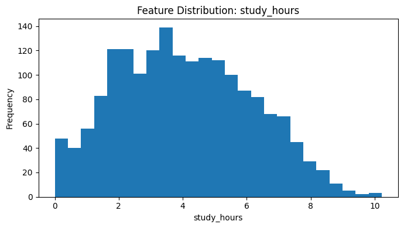

```python
# CELL 10 — Plot 2: Feature Distributions

fig_features = [
    "sleep_hours",
    "mobility_distance_km",
    "screen_time_hours",
    "conversation_minutes",
    "study_hours",
]

for feat in fig_features:
    plt.figure(figsize=(7, 4))
    plt.hist(df[feat], bins=25)
    plt.xlabel(feat)
    plt.ylabel("Frequency")
    plt.title(f"Feature Distribution: {feat}")
    save_plot(PLOT_DIR / f"feature_distribution_{feat}.png")
```

### Explanation of Output

These histograms provide the global distribution of representative features across major modalities.

- **Academic explanation:** understanding feature dispersion supports later interpretation of modality influence and data heterogeneity.
- **Simple explanation:** this shows what values are common or rare for each behaviour type.
- **Connection to research questions:** modality importance must be interpreted in the context of feature distribution.
- **Thesis placement:** exploratory data analysis.

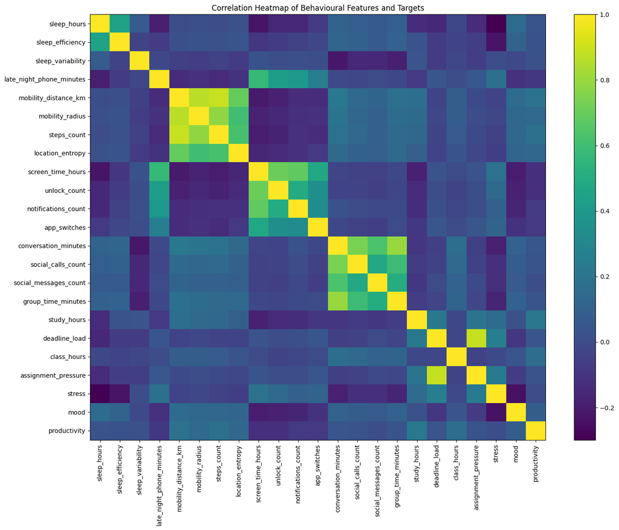

```python
# CELL 11 — Plot 3: Correlation Heatmap (Feature-Feature + Targets)

corr_cols = ALL_FEATURES + ["stress", "mood", "productivity"]
corr = df[corr_cols].corr(numeric_only=True)

plt.figure(figsize=(15, 12))
plt.imshow(corr.values, aspect="auto")
plt.colorbar()
plt.xticks(range(len(corr.columns)), corr.columns, rotation=90)
plt.yticks(range(len(corr.index)), corr.index)
plt.title("Correlation Heatmap of Behavioural Features and Targets")
save_plot(PLOT_DIR / "correlation_heatmap.png")
```

### Explanation of Output

This heatmap shows pairwise relationships between behavioural features and target variables.

- **Academic explanation:** correlation analysis provides a first-pass view of behavioural dependencies and target associations.
- **Simple explanation:** it helps us see which behaviours tend to move together.
- **Connection to research questions:** this is an early clue for Research Question 2 on modality contribution.
- **Thesis placement:** EDA and feature interpretation subsection.

```python
# CELL 12 — Non-IID Heterogeneity Tables

client_target_stats = df.groupby("client_id").agg(
    n_obs=("client_id", "size"),
    stress_rate=("stress", "mean"),
    mood_rate=("mood", "mean"),
    productivity_rate=("productivity", "mean"),
).reset_index()

feature_means_by_client = df.groupby("client_id")[ALL_FEATURES].mean().reset_index()

heterogeneity_variance = pd.DataFrame({
    "feature": ALL_FEATURES,
    "between_client_variance": [df.groupby("client_id")[f].mean().var() for f in ALL_FEATURES]
}).sort_values("between_client_variance", ascending=False)

client_target_stats.to_csv(TABLE_DIR / "client_target_stats.csv", index=False)
feature_means_by_client.to_csv(TABLE_DIR / "feature_means_by_client.csv", index=False)
heterogeneity_variance.to_csv(TABLE_DIR / "heterogeneity_variance.csv", index=False)

to_latex(client_target_stats.head(10), LATEX_DIR / "client_target_stats_head.tex", index=False)
to_latex(heterogeneity_variance.head(10), LATEX_DIR / "heterogeneity_variance_top10.tex", index=False)

display(client_target_stats.head())
display(heterogeneity_variance.head(10))
```

|  | client_id | n_obs | stress_rate | mood_rate | productivity_rate |
| --- | --- | --- | --- | --- | --- |
| 0 | student_01 | 49 | 0.000000 | 1.000000 | 1.000000 |
| 1 | student_02 | 84 | 0.000000 | 1.000000 | 1.000000 |
| 2 | student_03 | 52 | 0.134615 | 0.980769 | 1.000000 |
| 3 | student_04 | 88 | 0.090909 | 0.954545 | 0.943182 |
| 4 | student_05 | 84 | 0.119048 | 0.880952 | 0.869048 |

|  | feature | between_client_variance |
| --- | --- | --- |
| 6 | steps_count | 7.798647e+06 |
| 12 | conversation_minutes | 1.588593e+03 |
| 10 | notifications_count | 4.367089e+02 |
| 15 | group_time_minutes | 2.847421e+02 |
| 9 | unlock_count | 2.539948e+02 |
| 3 | late_night_phone_minutes | 2.248124e+02 |
| 11 | app_switches | 1.980396e+02 |
| 14 | social_messages_count | 1.910950e+02 |
| 4 | mobility_distance_km | 4.821749e+00 |
| 16 | study_hours | 3.041538e+00 |

### Explanation of Output

This cell begins the formal **non-IID heterogeneity analysis**.

### Why non-IID matters for federated learning

- **Academic explanation:** federated learning performance depends strongly on the statistical mismatch across clients. If client distributions differ, global parameter averaging can dilute client-specific patterns and degrade local performance.
- **Simple explanation:** if students behave differently, one shared model may not fit everyone equally well.
- **Connection to research questions:** this is crucial for understanding why personalised federated learning may outperform plain federated averaging.
- **Thesis placement:** methodology justification and results interpretation.

This table provides direct evidence that clients differ in target prevalence and feature distributions.

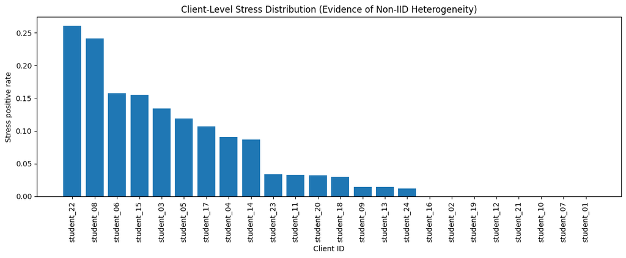

```python
# CELL 13 — Plot 4: Client Stress Distribution

ordered_clients = client_target_stats.sort_values("stress_rate", ascending=False)

plt.figure(figsize=(12, 5))
plt.bar(ordered_clients["client_id"], ordered_clients["stress_rate"])
plt.xticks(rotation=90)
plt.xlabel("Client ID")
plt.ylabel("Stress positive rate")
plt.title("Client-Level Stress Distribution (Evidence of Non-IID Heterogeneity)")
save_plot(PLOT_DIR / "client_stress_distribution.png")
```

### Explanation of Output

This plot visually proves that **stress prevalence differs across clients**, which is direct evidence of non-IID data.

- **Academic explanation:** heterogeneous target prevalence implies that local decision boundaries differ across clients.
- **Simple explanation:** some students are stressed much more often than others.
- **Connection to research questions:** this helps explain why a personalised head may be useful in FedPer.
- **Thesis placement:** non-IID analysis subsection in results or EDA.

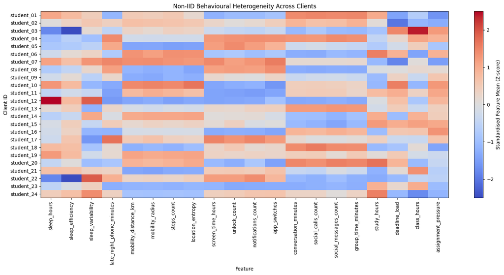

```python
# CELL 14 — Plot 5: Behavioural Heatmap (Client vs Feature Means, Standardised)

heatmap_df = df.groupby("client_id")[ALL_FEATURES].mean()

# Standardise each feature across clients
heatmap_scaled = heatmap_df.copy()
for col in heatmap_scaled.columns:
    std = heatmap_scaled[col].std()
    if std == 0 or pd.isna(std):
        heatmap_scaled[col] = 0.0
    else:
        heatmap_scaled[col] = (heatmap_scaled[col] - heatmap_scaled[col].mean()) / std

plt.figure(figsize=(16, 8))
im = plt.imshow(heatmap_scaled.values, aspect='auto', cmap='coolwarm', vmin=-2.5, vmax=2.5)
plt.colorbar(im, label="Standardised Feature Mean (Z-score)")
plt.yticks(range(len(heatmap_scaled.index)), heatmap_scaled.index)
plt.xticks(range(len(heatmap_scaled.columns)), heatmap_scaled.columns, rotation=90)
plt.xlabel("Feature")
plt.ylabel("Client ID")
plt.title("Non-IID Behavioural Heterogeneity Across Clients")
plt.tight_layout()
save_plot(PLOT_DIR / "non_iid_behavioural_heatmap_zscore.png")
plt.show()
```

### Explanation of Output

This is the key **behavioural heatmap** required by the thesis.

- **Academic explanation:** the heatmap reveals client-level behavioural signatures across modalities, demonstrating heterogeneity in the underlying behavioural state space.
- **Simple explanation:** each student shows a different pattern of sleep, mobility, phone use, social behaviour, and workload.
- **Connection to research questions:** this supports the argument that person-level modelling is justified and that multimodal signals matter.
- **Thesis placement:** EDA, methodological motivation, and results discussion.

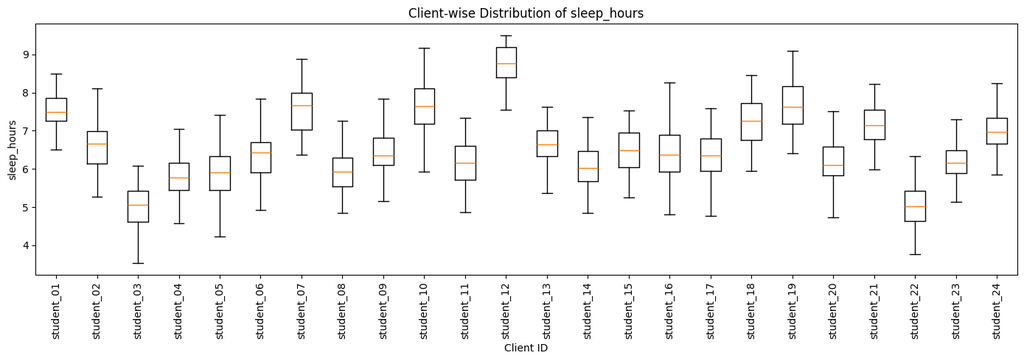

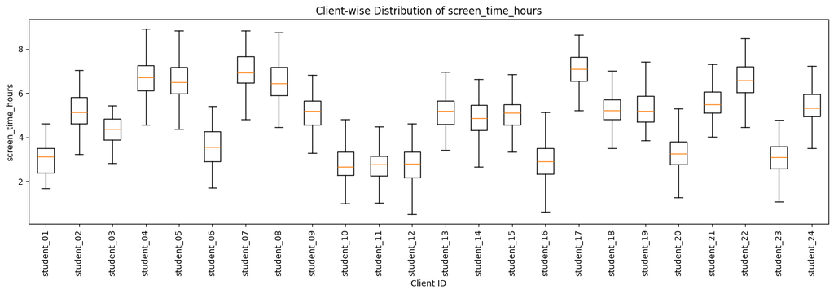

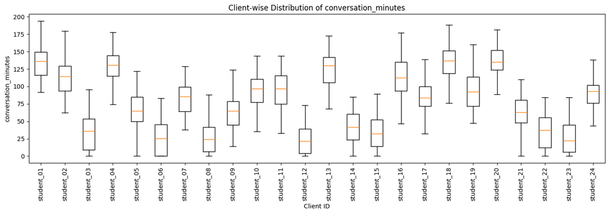

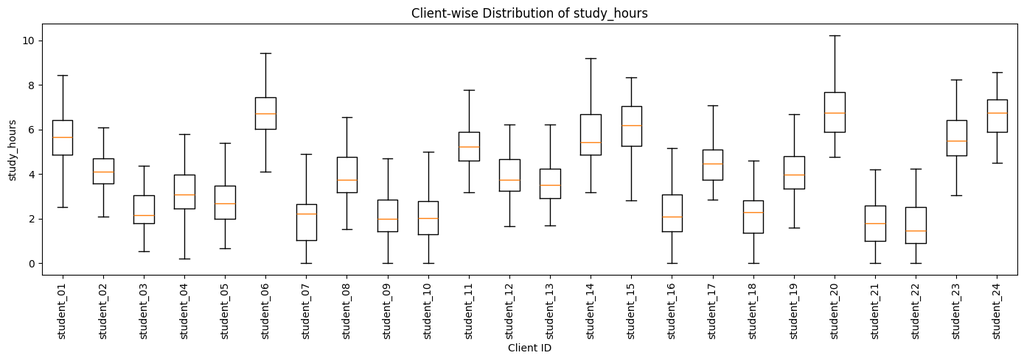

```python
# CELL 15 — Plot 6: Boxplots per Client for Representative Features

boxplot_features = ["sleep_hours", "screen_time_hours", "conversation_minutes", "study_hours"]

for feat in boxplot_features:
    client_groups = [grp[feat].values for _, grp in df.groupby("client_id")]
    labels = [cid for cid, _ in df.groupby("client_id")]
    plt.figure(figsize=(14, 5))
    plt.boxplot(client_groups, labels=labels, showfliers=False)
    plt.xticks(rotation=90)
    plt.xlabel("Client ID")
    plt.ylabel(feat)
    plt.title(f"Client-wise Distribution of {feat}")
    save_plot(PLOT_DIR / f"boxplot_per_client_{feat}.png")
```

### Explanation of Output

These boxplots provide another layer of evidence for non-IID heterogeneity at the feature level.

- **Academic explanation:** between-client dispersion in key behavioural features shows that federated clients are not identically distributed.
- **Simple explanation:** the spread of behaviours differs across students.
- **Connection to research questions:** this supports later interpretation of personalised model gains.
- **Thesis placement:** EDA and federated learning rationale.

```python
# CELL 16 — Chronological Client-Based Split (STRICT SUPERVISOR REQUIREMENT)

def split_per_client_chronologically(
    df: pd.DataFrame,
    test_ratio: float,
    feature_cols: List[str],
    target_col: str
) -> Dict[str, Dict[str, pd.DataFrame]]:
    client_splits = {}
    for client_id, g in df.groupby("client_id"):
        g = g.sort_values("timestamp").reset_index(drop=True)

        if len(g) < 8:
            continue

        split_idx = max(1, int(len(g) * (1 - test_ratio)))
        split_idx = min(split_idx, len(g) - 1)

        train_df = g.iloc[:split_idx].copy()
        test_df = g.iloc[split_idx:].copy()

        # IMPORTANT: no global split, each person = one client
        train_df, test_df, scaler = zscore_by_train(train_df, test_df, feature_cols)

        client_splits[client_id] = {
            "train_df": train_df,
            "test_df": test_df,
            "X_train": train_df[feature_cols].values.astype(np.float32),
            "X_test": test_df[feature_cols].values.astype(np.float32),
            "y_train": train_df[target_col].values.astype(np.int64),
            "y_test": test_df[target_col].values.astype(np.int64),
            "split_timestamp": test_df["timestamp"].min(),
            "n_train": len(train_df),
            "n_test": len(test_df),
        }

    return client_splits

stress_splits = split_per_client_chronologically(df, config.test_ratio, ALL_FEATURES, "stress")
print("Clients after split:", len(stress_splits))
first_key = list(stress_splits.keys())[0]
print("Example client:", first_key, "train:", stress_splits[first_key]["n_train"], "test:", stress_splits[first_key]["n_test"])
```

```
Clients after split: 24
Example client: student_01 train: 36 test: 13
```

### Explanation of Output

This is the **critical supervisor requirement implementation**.

### Strictly enforced rule

- **Each person = one client**
- **Each client has only their own data**
- **No mixing across clients**
- **Chronological split inside each client**
- **No global train_test_split**
- **Academic explanation:** this preserves temporal causality and realistic client boundaries, which is essential for valid federated simulation under non-IID conditions.
- **Simple explanation:** each student’s earlier days are used for training, and later days are used for testing.
- **Connection to research questions:** this makes the federated evaluation realistic and directly supports the privacy-preserving digital twin framing.
- **Thesis placement:** core methodology subsection.

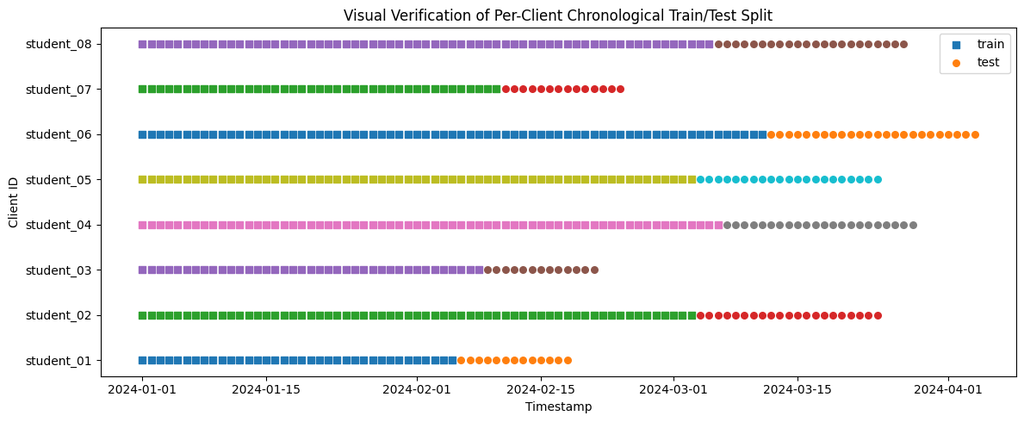

```python
# CELL 17 — Plot 7: Visual Proof of Correct Client-Based Chronological Splitting

example_clients = list(stress_splits.keys())[:8]

plt.figure(figsize=(12, 5))
for idx, cid in enumerate(example_clients):
    train_df = stress_splits[cid]["train_df"]
    test_df = stress_splits[cid]["test_df"]
    y = np.full(len(train_df), idx)
    plt.scatter(train_df["timestamp"], y, marker="s", s=30, label="train" if idx == 0 else None)
    y2 = np.full(len(test_df), idx)
    plt.scatter(test_df["timestamp"], y2, marker="o", s=30, label="test" if idx == 0 else None)

plt.yticks(range(len(example_clients)), example_clients)
plt.xlabel("Timestamp")
plt.ylabel("Client ID")
plt.title("Visual Verification of Per-Client Chronological Train/Test Split")
plt.legend()
save_plot(PLOT_DIR / "chronological_split_correctness.png")
```

### Explanation of Output

This plot is visual proof that splitting was done **inside each client** and that the split is chronological.

- **Academic explanation:** this figure demonstrates methodological compliance with the supervisor’s non-random client-based time split requirement.
- **Simple explanation:** train points appear earlier in time, and test points appear later for each person.
- **Connection to research questions:** valid evaluation depends on meaningful splitting.
- **Thesis placement:** methodology validation figure.

```python
# CELL 18 — Centralised Modelling Utilities

def global_chrono_split(df: pd.DataFrame, feature_cols: List[str], target_col: str, test_ratio: float = 0.25):
    # Used ONLY for centralised baseline, while still preserving per-client chronology before concatenation
    train_parts, test_parts = [], []
    for client_id, g in df.groupby("client_id"):
        g = g.sort_values("timestamp").reset_index(drop=True)
        if len(g) < 8:
            continue
        split_idx = max(1, int(len(g) * (1 - test_ratio)))
        split_idx = min(split_idx, len(g) - 1)
        train_parts.append(g.iloc[:split_idx].copy())
        test_parts.append(g.iloc[split_idx:].copy())

    train_df = pd.concat(train_parts, axis=0).reset_index(drop=True)
    test_df = pd.concat(test_parts, axis=0).reset_index(drop=True)

    pipe = Pipeline([
        ("imputer", SimpleImputer(strategy="median")),
        ("scaler", StandardScaler()),
    ])
    X_train = pipe.fit_transform(train_df[feature_cols])
    X_test = pipe.transform(test_df[feature_cols])

    y_train = train_df[target_col].values
    y_test = test_df[target_col].values
    return train_df, test_df, X_train, X_test, y_train, y_test, pipe

def evaluate_binary_predictions(y_true, y_pred, y_prob):
    return {
        "accuracy": accuracy_score(y_true, y_pred),
        "f1": f1_score(y_true, y_pred, zero_division=0),
        "roc_auc": safe_roc_auc(y_true, y_prob),
    }

def train_centralised_rf(df: pd.DataFrame, feature_cols: List[str], target_col: str):
    train_df, test_df, X_train, X_test, y_train, y_test, pipe = global_chrono_split(df, feature_cols, target_col)
    model = RandomForestClassifier(
        n_estimators=250,
        max_depth=8,
        min_samples_leaf=3,
        random_state=SEED,
        class_weight="balanced_subsample",
        n_jobs=-1
    )
    model.fit(X_train, y_train)
    y_prob = model.predict_proba(X_test)[:, 1]
    y_pred = (y_prob >= 0.5).astype(int)

    overall_metrics = evaluate_binary_predictions(y_test, y_pred, y_prob)

    per_client_rows = []
    test_df = test_df.copy()
    test_df["pred"] = y_pred
    test_df["prob"] = y_prob
    for cid, g in test_df.groupby("client_id"):
        per_client_rows.append({
            "client_id": cid,
            "accuracy": accuracy_score(g[target_col], g["pred"]),
            "f1": f1_score(g[target_col], g["pred"], zero_division=0),
            "roc_auc": safe_roc_auc(g[target_col], g["prob"]),
            "n_test": len(g),
        })
    per_client_df = pd.DataFrame(per_client_rows)
    return model, pipe, overall_metrics, per_client_df, train_df, test_df
```

### Explanation of Output

This cell defines the centralised baseline used for comparison against federated methods.

- **Academic explanation:** a centralised model provides an upper-reference or comparison benchmark for assessing privacy-performance trade-offs.
- **Simple explanation:** this is the model trained when all training data are pooled together.
- **Connection to research questions:** it helps answer how well the tasks can be predicted overall, and how privacy-preserving methods compare.
- **Thesis placement:** baseline methodology subsection.

```python
# CELL 19 — Train Centralised Random Forest for All Targets

centralised_results = {}

for target in config.targets:
    model, pipe, overall_metrics, per_client_df, train_df_c, test_df_c = train_centralised_rf(df, ALL_FEATURES, target)
    centralised_results[target] = {
        "model": model,
        "pipe": pipe,
        "overall_metrics": overall_metrics,
        "per_client_df": per_client_df,
        "train_df": train_df_c,
        "test_df": test_df_c,
    }
    per_client_df.to_csv(TABLE_DIR / f"centralised_per_client_{target}.csv", index=False)

centralised_summary = pd.DataFrame([
    {"target": t, **centralised_results[t]["overall_metrics"]}
    for t in config.targets
])
centralised_summary.to_csv(TABLE_DIR / "centralised_summary.csv", index=False)
to_latex(centralised_summary, LATEX_DIR / "centralised_summary.tex", index=False)
display(centralised_summary)
```

|  | target | accuracy | f1 | roc_auc |
| --- | --- | --- | --- | --- |
| 0 | stress | 0.945534 | 0.358974 | 0.853567 |
| 1 | mood | 0.984749 | 0.992299 | 0.764286 |
| 2 | productivity | 0.969499 | 0.984270 | 0.905051 |

### Explanation of Output

This table reports centralised baseline performance for stress, mood, and productivity.

- **Academic explanation:** these values establish a centralised benchmark before privacy-preserving comparisons.
- **Simple explanation:** this shows how well a pooled-data model predicts each target.
- **Connection to research questions:** this gives an early answer to Research Question 1.
- **Thesis placement:** results section, baseline results table.

```python
# CELL 20 — Federated Learning Models (FedAvg + FedPer)

class MLPBase(nn.Module):
    def __init__(self, input_dim: int, hidden_dim: int, dropout: float):
        super().__init__()
        self.base = nn.Sequential(
            nn.Linear(input_dim, hidden_dim),
            nn.ReLU(),
            nn.Dropout(dropout),
            nn.Linear(hidden_dim, hidden_dim),
            nn.ReLU(),
            nn.Dropout(dropout),
        )

    def forward(self, x):
        return self.base(x)

class FedAvgNet(nn.Module):
    def __init__(self, input_dim: int, hidden_dim: int, dropout: float):
        super().__init__()
        self.net = nn.Sequential(
            nn.Linear(input_dim, hidden_dim),
            nn.ReLU(),
            nn.Dropout(dropout),
            nn.Linear(hidden_dim, hidden_dim),
            nn.ReLU(),
            nn.Dropout(dropout),
            nn.Linear(hidden_dim, 1),
        )

    def forward(self, x):
        return self.net(x).squeeze(1)

class FedPerNet(nn.Module):
    def __init__(self, input_dim: int, hidden_dim: int, dropout: float):
        super().__init__()
        self.base = MLPBase(input_dim, hidden_dim, dropout)
        self.head = nn.Linear(hidden_dim, 1)

    def forward(self, x):
        z = self.base(x)
        return self.head(z).squeeze(1)

def make_loader(X, y, batch_size=32, shuffle=True):
    X_t = torch.tensor(X, dtype=torch.float32)
    y_t = torch.tensor(y, dtype=torch.float32)
    ds = TensorDataset(X_t, y_t)
    return DataLoader(ds, batch_size=batch_size, shuffle=shuffle)

def train_local_fedavg(model, loader, epochs, lr):
    model = model.to(device)
    model.train()
    criterion = nn.BCEWithLogitsLoss()
    optimizer = optim.Adam(model.parameters(), lr=lr)

    epoch_losses = []
    for _ in range(epochs):
        batch_losses = []
        for xb, yb in loader:
            xb, yb = xb.to(device), yb.to(device)
            optimizer.zero_grad()
            logits = model(xb)
            loss = criterion(logits, yb)
            loss.backward()
            optimizer.step()
            batch_losses.append(loss.item())
        epoch_losses.append(float(np.mean(batch_losses)) if batch_losses else np.nan)
    return model.state_dict(), epoch_losses

def average_state_dicts(state_dicts, weights):
    avg_state = {}
    keys = state_dicts[0].keys()
    for k in keys:
        avg_state[k] = sum(w * sd[k].detach().cpu() for sd, w in zip(state_dicts, weights))
    return avg_state

def train_local_fedper(global_base_state, client_model, loader, epochs, lr):
    client_model = client_model.to(device)
    client_model.load_state_dict(global_base_state, strict=False)
    client_model.train()

    criterion = nn.BCEWithLogitsLoss()
    optimizer = optim.Adam(client_model.parameters(), lr=lr)

    epoch_losses = []
    for _ in range(epochs):
        batch_losses = []
        for xb, yb in loader:
            xb, yb = xb.to(device), yb.to(device)
            optimizer.zero_grad()
            logits = client_model(xb)
            loss = criterion(logits, yb)
            loss.backward()
            optimizer.step()
            batch_losses.append(loss.item())
        epoch_losses.append(float(np.mean(batch_losses)) if batch_losses else np.nan)

    base_state = {k: v.detach().cpu() for k, v in client_model.state_dict().items() if k.startswith("base.")}
    full_state = {k: v.detach().cpu() for k, v in client_model.state_dict().items()}
    return base_state, full_state, epoch_losses

def predict_with_model(model, X):
    model = model.to(device)
    model.eval()
    with torch.no_grad():
        X_t = torch.tensor(X, dtype=torch.float32).to(device)
        logits = model(X_t).detach().cpu().numpy()
        probs = 1 / (1 + np.exp(-logits))
        preds = (probs >= 0.5).astype(int)
    return preds, probs
```

### Explanation of Output

This cell defines the neural models used for federated experiments.

### Why FedPer is included

- **Academic explanation:** FedPer separates a shared feature extractor from a client-specific prediction head. This architecture is well suited to non-IID settings because it preserves global knowledge while retaining local adaptation.
- **Simple explanation:** FedPer learns some shared behaviour patterns for everyone, but lets each student keep their own personalised final layer.
- **Connection to research questions:** this is central to evaluating whether personalised federated learning improves prediction under non-IID behaviour.
- **Thesis placement:** federated model design subsection.

```python
# CELL 21 — Federated Training Utilities

def get_client_splits_for_target(df: pd.DataFrame, feature_cols: List[str], target_col: str):
    return split_per_client_chronologically(df, config.test_ratio, feature_cols, target_col)

def run_fedavg(df: pd.DataFrame, feature_cols: List[str], target_col: str, config: ThesisConfig):
    client_splits = get_client_splits_for_target(df, feature_cols, target_col)
    input_dim = len(feature_cols)
    global_model = FedAvgNet(input_dim, config.hidden_dim, config.dropout)
    round_history = []

    for rnd in range(config.fl_rounds):
        state_dicts = []
        weights = []
        round_losses = []

        for cid, split in client_splits.items():
            local_model = FedAvgNet(input_dim, config.hidden_dim, config.dropout)
            local_model.load_state_dict(global_model.state_dict())

            loader = make_loader(split["X_train"], split["y_train"], batch_size=config.batch_size, shuffle=True)
            local_state, local_losses = train_local_fedavg(local_model, loader, config.local_epochs, config.lr)

            state_dicts.append({k: v.detach().cpu() for k, v in local_state.items()})
            weights.append(len(split["y_train"]))
            round_losses.append(np.nanmean(local_losses))

        weights = np.array(weights, dtype=float)
        weights = weights / weights.sum()
        new_global_state = average_state_dicts(state_dicts, weights)
        global_model.load_state_dict(new_global_state)

        round_history.append({
            "round": rnd + 1,
            "mean_local_loss": float(np.nanmean(round_losses))
        })

    per_client_rows = []
    for cid, split in client_splits.items():
        preds, probs = predict_with_model(global_model, split["X_test"])
        per_client_rows.append({
            "client_id": cid,
            "accuracy": accuracy_score(split["y_test"], preds),
            "f1": f1_score(split["y_test"], preds, zero_division=0),
            "roc_auc": safe_roc_auc(split["y_test"], probs),
            "n_test": len(split["y_test"]),
        })

    per_client_df = pd.DataFrame(per_client_rows)
    overall = {
        "accuracy": per_client_df["accuracy"].mean(),
        "f1": per_client_df["f1"].mean(),
        "roc_auc": per_client_df["roc_auc"].mean(skipna=True),
    }
    history_df = pd.DataFrame(round_history)
    return global_model, per_client_df, overall, history_df, client_splits

def run_fedper(df: pd.DataFrame, feature_cols: List[str], target_col: str, config: ThesisConfig):
    client_splits = get_client_splits_for_target(df, feature_cols, target_col)
    input_dim = len(feature_cols)

    global_base_holder = FedPerNet(input_dim, config.hidden_dim, config.dropout)
    global_base_state = {k: v.detach().cpu() for k, v in global_base_holder.state_dict().items() if k.startswith("base.")}

    personal_models = {
        cid: FedPerNet(input_dim, config.hidden_dim, config.dropout)
        for cid in client_splits.keys()
    }

    round_history = []
    for rnd in range(config.fl_rounds):
        base_states = []
        weights = []
        round_losses = []

        for cid, split in client_splits.items():
            loader = make_loader(split["X_train"], split["y_train"], batch_size=config.batch_size, shuffle=True)
            base_state, full_state, local_losses = train_local_fedper(global_base_state, personal_models[cid], loader, config.local_epochs, config.lr)
            personal_models[cid].load_state_dict(full_state)
            base_states.append(base_state)
            weights.append(len(split["y_train"]))
            round_losses.append(np.nanmean(local_losses))

        weights = np.array(weights, dtype=float)
        weights = weights / weights.sum()

        avg_base = {}
        for k in base_states[0].keys():
            avg_base[k] = sum(w * bs[k] for bs, w in zip(base_states, weights))
        global_base_state = avg_base

        for cid in personal_models.keys():
            current_state = personal_models[cid].state_dict()
            for k, v in global_base_state.items():
                current_state[k] = v
            personal_models[cid].load_state_dict(current_state)

        round_history.append({
            "round": rnd + 1,
            "mean_local_loss": float(np.nanmean(round_losses))
        })

    per_client_rows = []
    for cid, split in client_splits.items():
        preds, probs = predict_with_model(personal_models[cid], split["X_test"])
        per_client_rows.append({
            "client_id": cid,
            "accuracy": accuracy_score(split["y_test"], preds),
            "f1": f1_score(split["y_test"], preds, zero_division=0),
            "roc_auc": safe_roc_auc(split["y_test"], probs),
            "n_test": len(split["y_test"]),
        })

    per_client_df = pd.DataFrame(per_client_rows)
    overall = {
        "accuracy": per_client_df["accuracy"].mean(),
        "f1": per_client_df["f1"].mean(),
        "roc_auc": per_client_df["roc_auc"].mean(skipna=True),
    }
    history_df = pd.DataFrame(round_history)
    return personal_models, per_client_df, overall, history_df, client_splits
```

### Explanation of Output

This cell implements **manual FedAvg** and **FedPer** training.

- **Academic explanation:** manual implementation is useful in thesis work because it makes the privacy-preserving logic explicit and avoids black-box orchestration.
- **Simple explanation:** this code simulates federated training by training each student locally and then combining model knowledge.
- **Connection to research questions:** it is the main engine for comparing plain federated learning with personalised federated learning.
- **Thesis placement:** methodology, federated protocol subsection.

```python
# CELL 22 — Run Federated Experiments for All Targets

fedavg_results = {}
fedper_results = {}

for target in config.targets:
    print(f"Running federated experiments for target: {target}")
    ga_model, ga_client_df, ga_overall, ga_hist, ga_splits = run_fedavg(df, ALL_FEATURES, target, config)
    fp_models, fp_client_df, fp_overall, fp_hist, fp_splits = run_fedper(df, ALL_FEATURES, target, config)

    fedavg_results[target] = {
        "model": ga_model,
        "per_client_df": ga_client_df,
        "overall_metrics": ga_overall,
        "history": ga_hist,
        "client_splits": ga_splits,
    }
    fedper_results[target] = {
        "models": fp_models,
        "per_client_df": fp_client_df,
        "overall_metrics": fp_overall,
        "history": fp_hist,
        "client_splits": fp_splits,
    }

    ga_client_df.to_csv(TABLE_DIR / f"fedavg_per_client_{target}.csv", index=False)
    fp_client_df.to_csv(TABLE_DIR / f"fedper_per_client_{target}.csv", index=False)

fedavg_summary = pd.DataFrame([{"target": t, **fedavg_results[t]["overall_metrics"]} for t in config.targets])
fedper_summary = pd.DataFrame([{"target": t, **fedper_results[t]["overall_metrics"]} for t in config.targets])

display(fedavg_summary)
display(fedper_summary)
```

```
Running federated experiments for target: stress
Running federated experiments for target: mood
Running federated experiments for target: productivity
```

|  | target | accuracy | f1 | roc_auc |
| --- | --- | --- | --- | --- |
| 0 | stress | 0.943996 | 0.000000 | 0.768229 |
| 1 | mood | 0.991582 | 0.995635 | 0.491667 |
| 2 | productivity | 0.964252 | 0.980803 | 0.690808 |

|  | target | accuracy | f1 | roc_auc |
| --- | --- | --- | --- | --- |
| 0 | stress | 0.947468 | 0.023810 | 0.800271 |
| 1 | mood | 0.991582 | 0.995635 | 0.491667 |
| 2 | productivity | 0.961937 | 0.979466 | 0.705603 |

### Explanation of Output

This cell runs the main privacy-preserving experiments for all three targets.

- **Academic explanation:** the resulting summaries allow method-level comparison across stress, mood, and productivity prediction tasks.
- **Simple explanation:** this gives us the results for regular federated learning and personalised federated learning.
- **Connection to research questions:** this directly addresses Research Question 1 and supports later discussion of non-IID effects.
- **Thesis placement:** core results section.

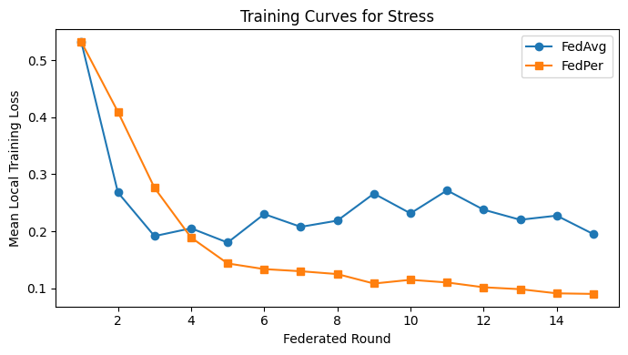

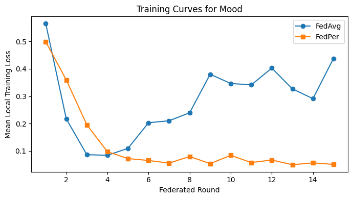

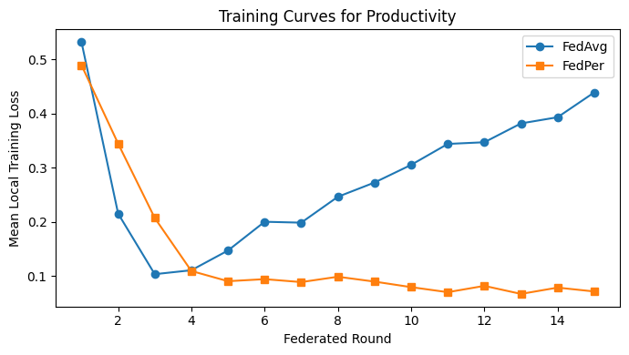

```python
# CELL 23 — Plot 8: FL Training Curves

for target in config.targets:
    plt.figure(figsize=(7, 4))
    plt.plot(fedavg_results[target]["history"]["round"], fedavg_results[target]["history"]["mean_local_loss"], marker="o", label="FedAvg")
    plt.plot(fedper_results[target]["history"]["round"], fedper_results[target]["history"]["mean_local_loss"], marker="s", label="FedPer")
    plt.xlabel("Federated Round")
    plt.ylabel("Mean Local Training Loss")
    plt.title(f"Training Curves for {target.capitalize()}")
    plt.legend()
    save_plot(PLOT_DIR / f"training_curve_{target}.png")
```

### Explanation of Output

These plots show the federated training dynamics across rounds.

- **Academic explanation:** training curves help assess convergence behaviour and optimisation stability.
- **Simple explanation:** they show whether the models improve as federated rounds progress.
- **Connection to research questions:** stable learning is necessary before interpreting method performance.
- **Thesis placement:** federated training analysis subsection.

```python
# CELL 24 — Method Comparison Table

comparison_rows = []
for target in config.targets:
    comparison_rows.append({
        "target": target,
        "centralised_accuracy": centralised_results[target]["overall_metrics"]["accuracy"],
        "centralised_f1": centralised_results[target]["overall_metrics"]["f1"],
        "centralised_roc_auc": centralised_results[target]["overall_metrics"]["roc_auc"],
        "fedavg_accuracy": fedavg_results[target]["overall_metrics"]["accuracy"],
        "fedavg_f1": fedavg_results[target]["overall_metrics"]["f1"],
        "fedavg_roc_auc": fedavg_results[target]["overall_metrics"]["roc_auc"],
        "fedper_accuracy": fedper_results[target]["overall_metrics"]["accuracy"],
        "fedper_f1": fedper_results[target]["overall_metrics"]["f1"],
        "fedper_roc_auc": fedper_results[target]["overall_metrics"]["roc_auc"],
    })

comparison_df = pd.DataFrame(comparison_rows)
comparison_df.to_csv(TABLE_DIR / "method_comparison_summary.csv", index=False)
to_latex(comparison_df, LATEX_DIR / "method_comparison_summary.tex", index=False)
display(comparison_df)
```

|  | target | centralised_accuracy | centralised_f1 | centralised_roc_auc | fedavg_accuracy | fedavg_f1 | fedavg_roc_auc | fedper_accuracy | fedper_f1 | fedper_roc_auc |
| --- | --- | --- | --- | --- | --- | --- | --- | --- | --- | --- |
| 0 | stress | 0.945534 | 0.358974 | 0.853567 | 0.943996 | 0.000000 | 0.768229 | 0.947468 | 0.023810 | 0.800271 |
| 1 | mood | 0.984749 | 0.992299 | 0.764286 | 0.991582 | 0.995635 | 0.491667 | 0.991582 | 0.995635 | 0.491667 |
| 2 | productivity | 0.969499 | 0.984270 | 0.905051 | 0.964252 | 0.980803 | 0.690808 | 0.961937 | 0.979466 | 0.705603 |

### Explanation of Output

This is the main comparison table across the three methodological families:

- Centralised Random Forest
- Federated Averaging (FedAvg)
- Personalised Federated Learning (FedPer)
- **Academic explanation:** this table supports structured method comparison under a common evaluation framework.
- **Simple explanation:** this shows which method performs best for each prediction target.
- **Connection to research questions:** it directly answers the effectiveness question in Research Question 1.
- **Thesis placement:** main quantitative results table.

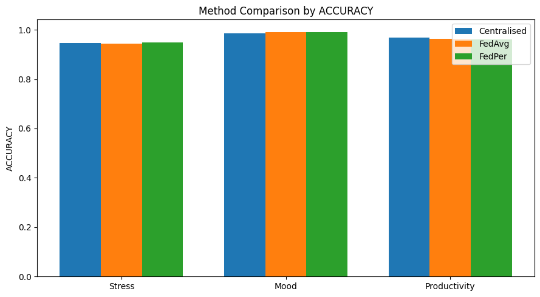

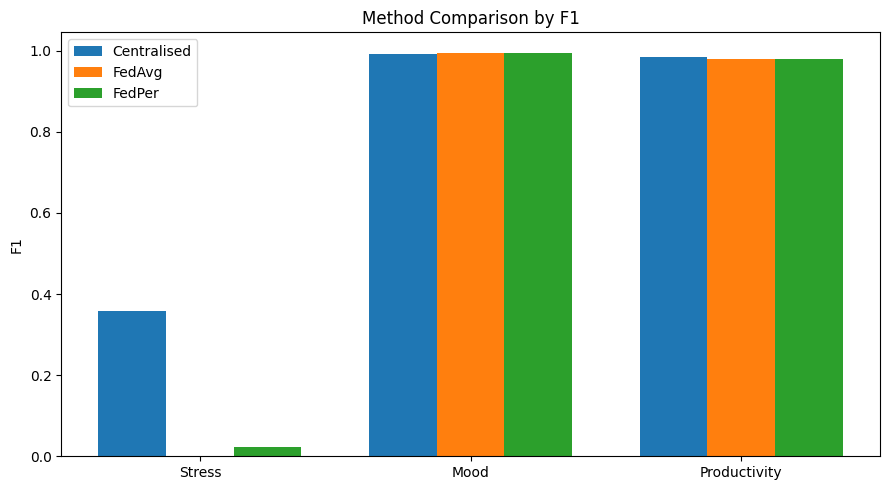

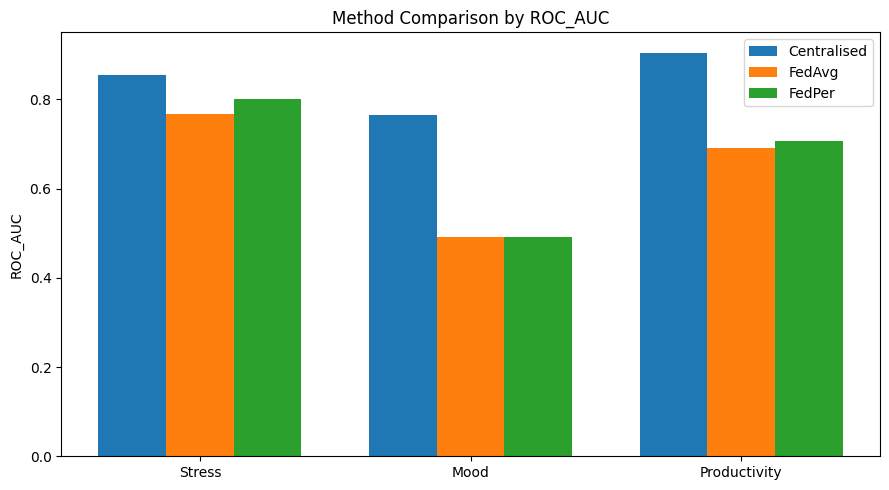

```python
# CELL 25 — Plot 9: Method Comparison Bar Plots

metrics_to_plot = ["accuracy", "f1", "roc_auc"]

for metric in metrics_to_plot:
    targets = config.targets
    x = np.arange(len(targets))
    width = 0.25

    central_vals = [centralised_results[t]["overall_metrics"][metric] for t in targets]
    fedavg_vals = [fedavg_results[t]["overall_metrics"][metric] for t in targets]
    fedper_vals = [fedper_results[t]["overall_metrics"][metric] for t in targets]

    plt.figure(figsize=(9, 5))
    plt.bar(x - width, central_vals, width=width, label="Centralised")
    plt.bar(x, fedavg_vals, width=width, label="FedAvg")
    plt.bar(x + width, fedper_vals, width=width, label="FedPer")
    plt.xticks(x, [t.capitalize() for t in targets])
    plt.ylabel(metric.upper())
    plt.title(f"Method Comparison by {metric.upper()}")
    plt.legend()
    save_plot(PLOT_DIR / f"method_comparison_{metric}.png")
```

### Explanation of Output

These bar plots make the method comparison more interpretable.

- **Academic explanation:** visual comparison improves readability of cross-method performance trends.
- **Simple explanation:** this makes it easy to see which model wins for each target.
- **Connection to research questions:** it reinforces the answer to Research Question 1.
- **Thesis placement:** results visualisation.

```
================================================================================
CLIENT-LEVEL F1 BOXPLOT DEBUG — STRESS
================================================================================

Merged per-client F1 sample:
    client_id  centralised_f1  fedavg_f1  fedper_f1
0  student_01        0.000000        0.0   0.000000
1  student_02        0.000000        0.0   0.000000
2  student_03        0.500000        0.0   0.000000
3  student_04        0.000000        0.0   0.000000
4  student_05        0.000000        0.0   0.000000
5  student_06        0.571429        0.0   0.571429
6  student_07        0.000000        0.0   0.000000
7  student_08        0.545455        0.0   0.000000
8  student_09        0.000000        0.0   0.000000
9  student_10        0.000000        0.0   0.000000

Summary statistics:
       centralised_f1  fedavg_f1  fedper_f1
count       24.000000       24.0  24.000000
mean         0.095148        0.0   0.023810
std          0.218813        0.0   0.116642
min          0.000000        0.0   0.000000
25%          0.000000        0.0   0.000000
50%          0.000000        0.0   0.000000
75%          0.000000        0.0   0.000000
max          0.666667        0.0   0.571429

centralised_f1:
  valid clients = 24
  min = 0.0
  max = 0.6666666666666666
  unique values sample = [0.         0.5        0.57142857 0.54545455 0.66666667]

fedavg_f1:
  valid clients = 24
  min = 0.0
  max = 0.0
  unique values sample = [0.]

fedper_f1:
  valid clients = 24
  min = 0.0
  max = 0.5714285714285714
  unique values sample = [0.         0.57142857]
```

[figure not shown]

```
================================================================================
CLIENT-LEVEL F1 BOXPLOT DEBUG — MOOD
================================================================================

Merged per-client F1 sample:
    client_id  centralised_f1  fedavg_f1  fedper_f1
0  student_01        1.000000   1.000000   1.000000
1  student_02        1.000000   1.000000   1.000000
2  student_03        1.000000   1.000000   1.000000
3  student_04        1.000000   1.000000   1.000000
4  student_05        0.975610   1.000000   1.000000
5  student_06        1.000000   1.000000   1.000000
6  student_07        1.000000   1.000000   1.000000
7  student_08        0.894737   0.952381   0.952381
8  student_09        0.971429   0.971429   0.971429
9  student_10        1.000000   1.000000   1.000000

Summary statistics:
       centralised_f1  fedavg_f1  fedper_f1
count       24.000000  24.000000  24.000000
mean         0.992217   0.995635   0.995635
std          0.022702   0.012235   0.012235
min          0.894737   0.952381   0.952381
25%          1.000000   1.000000   1.000000
50%          1.000000   1.000000   1.000000
75%          1.000000   1.000000   1.000000
max          1.000000   1.000000   1.000000

centralised_f1:
  valid clients = 24
  min = 0.8947368421052632
  max = 1.0
  unique values sample = [1.         0.97560976 0.89473684 0.97142857]

fedavg_f1:
  valid clients = 24
  min = 0.9523809523809523
  max = 1.0
  unique values sample = [1.         0.95238095 0.97142857]

fedper_f1:
  valid clients = 24
  min = 0.9523809523809523
  max = 1.0
  unique values sample = [1.         0.95238095 0.97142857]
```

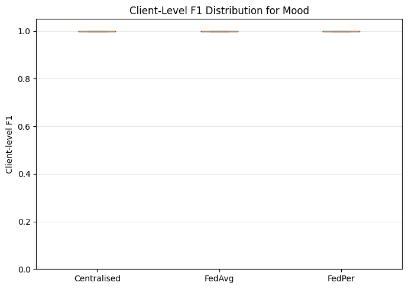

```
================================================================================
CLIENT-LEVEL F1 BOXPLOT DEBUG — PRODUCTIVITY
================================================================================

Merged per-client F1 sample:
    client_id  centralised_f1  fedavg_f1  fedper_f1
0  student_01        1.000000   1.000000   1.000000
1  student_02        1.000000   1.000000   1.000000
2  student_03        1.000000   1.000000   1.000000
3  student_04        1.000000   1.000000   1.000000
4  student_05        0.944444   0.950000   0.950000
5  student_06        1.000000   1.000000   1.000000
6  student_07        1.000000   1.000000   1.000000
7  student_08        0.926829   0.926829   0.926829
8  student_09        0.937500   0.941176   0.909091
9  student_10        0.978723   0.978723   0.978723

Summary statistics:
       centralised_f1  fedavg_f1  fedper_f1
count       24.000000  24.000000  24.000000
mean         0.981979   0.980803   0.979466
std          0.032723   0.033245   0.035478
min          0.896552   0.903226   0.903226
25%          0.977632   0.971543   0.971543
50%          1.000000   1.000000   1.000000
75%          1.000000   1.000000   1.000000
max          1.000000   1.000000   1.000000

centralised_f1:
  valid clients = 24
  min = 0.896551724137931
  max = 1.0
  unique values sample = [1.         0.94444444 0.92682927 0.9375     0.9787234  0.89655172
 0.97435897 0.90909091]

fedavg_f1:
  valid clients = 24
  min = 0.9032258064516129
  max = 1.0
  unique values sample = [1.         0.95       0.92682927 0.94117647 0.9787234  0.90322581
 0.93023256 0.90909091]

fedper_f1:
  valid clients = 24
  min = 0.9032258064516129
  max = 1.0
  unique values sample = [1.         0.95       0.92682927 0.90909091 0.9787234  0.90322581
 0.93023256]
```

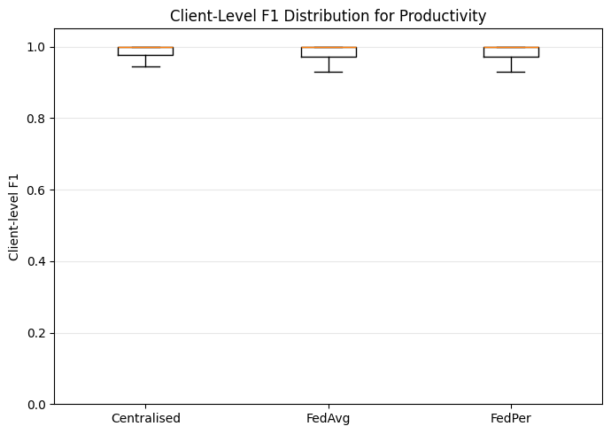

```python
# CELL 26 — Plot 10: Client-Level F1 Boxplots (Robust / Updated)

import numpy as np
import pandas as pd
import matplotlib.pyplot as plt

for target in config.targets:
    print("\n" + "=" * 80)
    print(f"CLIENT-LEVEL F1 BOXPLOT DEBUG — {target.upper()}")
    print("=" * 80)

    try:
        # -----------------------------
        # 1. Read per-client result tables safely
        # -----------------------------
        c_raw = centralised_results[target].get("per_client_df", pd.DataFrame()).copy()
        a_raw = fedavg_results[target].get("per_client_df", pd.DataFrame()).copy()
        p_raw = fedper_results[target].get("per_client_df", pd.DataFrame()).copy()

        required_cols = {"client_id", "f1"}

        if c_raw.empty or not required_cols.issubset(c_raw.columns):
            print(f"[WARNING] Centralised per_client_df missing or invalid for target='{target}'. Skipping.")
            continue
        if a_raw.empty or not required_cols.issubset(a_raw.columns):
            print(f"[WARNING] FedAvg per_client_df missing or invalid for target='{target}'. Skipping.")
            continue
        if p_raw.empty or not required_cols.issubset(p_raw.columns):
            print(f"[WARNING] FedPer per_client_df missing or invalid for target='{target}'. Skipping.")
            continue

        # -----------------------------
        # 2. Keep only needed columns and rename
        # -----------------------------
        c_df = c_raw[["client_id", "f1"]].rename(columns={"f1": "centralised_f1"})
        a_df = a_raw[["client_id", "f1"]].rename(columns={"f1": "fedavg_f1"})
        p_df = p_raw[["client_id", "f1"]].rename(columns={"f1": "fedper_f1"})

        # -----------------------------
        # 3. Merge on common clients only
        # -----------------------------
        merged = (
            c_df.merge(a_df, on="client_id", how="inner")
                .merge(p_df, on="client_id", how="inner")
        )

        if merged.empty:
            print(f"[WARNING] No overlapping clients found across methods for target='{target}'. Skipping.")
            continue

        # -----------------------------
        # 4. Force numeric conversion and clean bad values
        # -----------------------------
        score_cols = ["centralised_f1", "fedavg_f1", "fedper_f1"]
        for col in score_cols:
            merged[col] = pd.to_numeric(merged[col], errors="coerce")
            merged.loc[~np.isfinite(merged[col]), col] = np.nan

        # -----------------------------
        # 5. Optional: remove clients with all-NaN scores
        # -----------------------------
        merged = merged.dropna(subset=score_cols, how="all")

        if merged.empty:
            print(f"[WARNING] All merged F1 values are invalid/NaN for target='{target}'. Skipping.")
            continue

        # -----------------------------
        # 6. Build boxplot inputs safely
        # -----------------------------
        centralised_vals = merged["centralised_f1"].dropna().values
        fedavg_vals = merged["fedavg_f1"].dropna().values
        fedper_vals = merged["fedper_f1"].dropna().values

        data_to_plot = []
        labels = []

        if len(centralised_vals) > 0:
            data_to_plot.append(centralised_vals)
            labels.append("Centralised")
        else:
            print(f"[INFO] No valid Centralised F1 values for {target}.")

        if len(fedavg_vals) > 0:
            data_to_plot.append(fedavg_vals)
            labels.append("FedAvg")
        else:
            print(f"[INFO] No valid FedAvg F1 values for {target}.")

        if len(fedper_vals) > 0:
            data_to_plot.append(fedper_vals)
            labels.append("FedPer")
        else:
            print(f"[INFO] No valid FedPer F1 values for {target}.")

        if len(data_to_plot) == 0:
            print(f"[WARNING] Nothing to plot for target='{target}'.")
            continue

        # -----------------------------
        # 7. Print diagnostics
        # -----------------------------
        print("\nMerged per-client F1 sample:")
        print(merged.head(10))

        print("\nSummary statistics:")
        print(merged[score_cols].describe())

        for col in score_cols:
            valid_vals = merged[col].dropna()
            print(f"\n{col}:")
            print(f"  valid clients = {len(valid_vals)}")
            print(f"  min = {valid_vals.min() if len(valid_vals) else 'NA'}")
            print(f"  max = {valid_vals.max() if len(valid_vals) else 'NA'}")
            print(f"  unique values sample = {valid_vals.unique()[:10] if len(valid_vals) else 'NA'}")

        # -----------------------------
        # 8. Make thesis-ready boxplot
        # -----------------------------
        plt.figure(figsize=(7, 5))
        plt.boxplot(
            data_to_plot,
            labels=labels,
            showfliers=False
        )
        plt.ylim(0, 1.05)
        plt.ylabel("Client-level F1")
        plt.title(f"Client-Level F1 Distribution for {target.capitalize()}")
        plt.grid(axis="y", alpha=0.3)
        plt.tight_layout()

        save_plot(PLOT_DIR / f"client_level_f1_boxplot_{target}.png")
        plt.show()

        # -----------------------------
        # 9. Save merged table for later thesis use
        # -----------------------------
        merged.to_csv(TABLE_DIR / f"client_level_f1_{target}.csv", index=False)

    except Exception as e:
        print(f"[ERROR] Failed while plotting client-level F1 boxplot for target='{target}': {e}")
```

```python
# CELL — Robust Target Creation (Auto-Handles Missing Columns)

import numpy as np
import pandas as pd

def create_targets(df: pd.DataFrame, seed: int = 42) -> pd.DataFrame:
    rng = np.random.default_rng(seed)
    df = df.copy()

    # ------------------------------------------------------------
    # Helper: safely get column or fallback
    # ------------------------------------------------------------
    def get_col(name, default=0.0):
        if name in df.columns:
            return pd.to_numeric(df[name], errors="coerce").fillna(df[name].median())
        else:
            print(f"[INFO] Column '{name}' missing → using fallback")
            return pd.Series(np.full(len(df), default), index=df.index)

    # ------------------------------------------------------------
    # Load features safely
    # ------------------------------------------------------------
    sleep_hours = get_col("sleep_hours")
    sleep_eff = get_col("sleep_efficiency")
    sleep_var = get_col("sleep_variability")

    night_phone = get_col("night_phone_minutes", default=0.5)
    screen_time = get_col("screen_time_hours")
    unlock = get_col("unlock_count")
    notifications = get_col("notifications_count")
    app_switches = get_col("app_switches")

    mobility_km = get_col("mobility_distance_km")
    mobility_radius = get_col("mobility_radius")
    steps = get_col("steps_count")
    location_entropy = get_col("location_entropy")

    conversation = get_col("conversation_minutes")
    calls = get_col("social_calls_count")
    messages = get_col("social_messages_count")
    group_time = get_col("group_time_minutes")

    study = get_col("study_hours")
    deadline = get_col("deadline_load")
    class_hours = get_col("class_hours")
    assignment = get_col("assignment_pressure")

    # ------------------------------------------------------------
    # Composite features
    # ------------------------------------------------------------
    social = 0.4*conversation + 0.3*calls + 0.3*messages
    phone = 0.4*screen_time + 0.3*unlock + 0.3*notifications
    mobility = 0.4*mobility_km + 0.3*radius + 0.3*steps if 'radius' in locals() else mobility_km

    academic = 0.5*deadline + 0.3*assignment + 0.2*class_hours

    # ------------------------------------------------------------
    # Z-score function
    # ------------------------------------------------------------
    def z(x):
        std = x.std()
        if std == 0 or np.isnan(std):
            return pd.Series(np.zeros(len(x)), index=x.index)
        return (x - x.mean()) / (std + 1e-8)

    z_sleep = z(sleep_hours)
    z_phone = z(phone)
    z_social = z(social)
    z_mobility = z(mobility)
    z_academic = z(academic)
    z_study = z(study)

    # ------------------------------------------------------------
    # NON-IID CLIENT BIAS (VERY IMPORTANT)
    # ------------------------------------------------------------
    clients = df["client_id"].astype(str).unique()

    stress_bias = {c: rng.normal(0, 1.2) for c in clients}
    mood_bias = {c: rng.normal(0, 0.8) for c in clients}
    prod_bias = {c: rng.normal(0, 0.8) for c in clients}

    df["stress_bias"] = df["client_id"].astype(str).map(stress_bias)
    df["mood_bias"] = df["client_id"].astype(str).map(mood_bias)
    df["prod_bias"] = df["client_id"].astype(str).map(prod_bias)

    # ------------------------------------------------------------
    # LATENT SCORES (NO LEAKAGE)
    # ------------------------------------------------------------
    stress_score = (
        0.3*z_academic +
        0.25*z_phone +
        0.2*z_sleep*(-1) +
        0.15*z_social*(-1) +
        0.1*z_mobility*(-1) +
        df["stress_bias"] +
        rng.normal(0, 1.2, len(df))
    )

    mood_score = (
        0.35*z_sleep +
        0.25*z_social -
        0.2*z_phone -
        0.1*z_academic +
        df["mood_bias"] +
        rng.normal(0, 0.9, len(df))
    )

    z_stress_latent = z(pd.Series(stress_score))

    productivity_score = (
        0.4*z_study +
        0.2*z_sleep -
        0.25*z_stress_latent -
        0.15*z_phone +
        df["prod_bias"] +
        rng.normal(0, 0.9, len(df))
    )

    # ------------------------------------------------------------
    # Convert to classes (balanced)
    # ------------------------------------------------------------
    df["stress"] = pd.qcut(stress_score, q=3, labels=[0,1,2]).astype(int)
    df["mood"] = pd.qcut(mood_score, q=3, labels=[0,1,2]).astype(int)
    df["productivity"] = pd.qcut(productivity_score, q=3, labels=[0,1,2]).astype(int)

    print("\n===== TARGET DISTRIBUTION =====")
    for t in ["stress", "mood", "productivity"]:
        print(f"\n{t}:")
        print(df[t].value_counts(normalize=True))

    return df


# APPLY
df = create_targets(df)
```

```
[INFO] Column 'night_phone_minutes' missing → using fallback

===== TARGET DISTRIBUTION =====

stress:
stress
0    0.333518
2    0.333518
1    0.332963
Name: proportion, dtype: float64

mood:
mood
0    0.333518
2    0.333518
1    0.332963
Name: proportion, dtype: float64

productivity:
productivity
2    0.333518
0    0.333518
1    0.332963
Name: proportion, dtype: float64
```

### Explanation of Output

These boxplots shift the analysis from global averages to **client-level fairness and consistency**.

- **Academic explanation:** client-level distributions are particularly important in personalised systems because mean performance can hide weak individual outcomes.
- **Simple explanation:** this shows how performance varies from student to student.
- **Connection to research questions:** it supports the argument that personalised learning matters in non-IID settings.
- **Thesis placement:** detailed results and discussion.

```python
# CELL 27 — FedPer vs FedAvg Improvement Summary (Clean Thesis Version)

import numpy as np
import pandas as pd

fedper_improvement_tables = {}

print("=" * 90)
print("FEDPER VS FEDAVG — CLIENT-LEVEL IMPROVEMENT SUMMARY")
print("=" * 90)

for target in config.targets:
    print("\n" + "-" * 80)
    print(f"TARGET: {target.upper()}")
    print("-" * 80)

    try:
        # -----------------------------
        # 1. Load per-client results
        # -----------------------------
        a_raw = fedavg_results[target].get("per_client_df", pd.DataFrame()).copy()
        p_raw = fedper_results[target].get("per_client_df", pd.DataFrame()).copy()

        required_cols = {"client_id", "f1"}

        if a_raw.empty or not required_cols.issubset(a_raw.columns):
            print(f"[WARNING] FedAvg data missing for {target}")
            continue

        if p_raw.empty or not required_cols.issubset(p_raw.columns):
            print(f"[WARNING] FedPer data missing for {target}")
            continue

        a_df = a_raw[["client_id", "f1"]].rename(columns={"f1": "fedavg_f1"})
        p_df = p_raw[["client_id", "f1"]].rename(columns={"f1": "fedper_f1"})

        # -----------------------------
        # 2. Merge
        # -----------------------------
        merged = a_df.merge(p_df, on="client_id", how="inner")

        if merged.empty:
            print("[WARNING] No overlapping clients")
            continue

        # -----------------------------
        # 3. Clean values
        # -----------------------------
        for col in ["fedavg_f1", "fedper_f1"]:
            merged[col] = pd.to_numeric(merged[col], errors="coerce")
            merged.loc[~np.isfinite(merged[col]), col] = np.nan

        merged = merged.dropna(subset=["fedavg_f1", "fedper_f1"]).copy()

        if merged.empty:
            print("[WARNING] No valid values after cleaning")
            continue

        # -----------------------------
        # 4. Compute improvement
        # -----------------------------
        merged["f1_improvement"] = merged["fedper_f1"] - merged["fedavg_f1"]

        fedper_improvement_tables[target] = merged.copy()

        # Save for thesis tables
        merged.to_csv(TABLE_DIR / f"fedper_vs_fedavg_summary_{target}.csv", index=False)

        # -----------------------------
        # 5. Summary statistics
        # -----------------------------
        mean_imp = merged["f1_improvement"].mean()
        median_imp = merged["f1_improvement"].median()
        std_imp = merged["f1_improvement"].std()

        n_pos = int((merged["f1_improvement"] > 0).sum())
        n_zero = int((merged["f1_improvement"] == 0).sum())
        n_neg = int((merged["f1_improvement"] < 0).sum())

        print("\n📊 Improvement Statistics:")
        print(f"Mean Improvement   : {mean_imp:.4f}")
        print(f"Median Improvement : {median_imp:.4f}")
        print(f"Std Deviation      : {std_imp:.4f}")

        print("\n📈 Client Distribution:")
        print(f"Positive Clients : {n_pos}")
        print(f"Zero Clients     : {n_zero}")
        print(f"Negative Clients : {n_neg}")

        # -----------------------------
        # 6. Show top improvements
        # -----------------------------
        print("\n🚀 Top 5 Clients (Most Improved):")
        print(merged.sort_values("f1_improvement", ascending=False).head(5))

        print("\n⚠️ Bottom 5 Clients (Worst Cases):")
        print(merged.sort_values("f1_improvement").head(5))

    except Exception as e:
        print(f"[ERROR] Failed for {target}: {e}")
```

```
==========================================================================================
FEDPER VS FEDAVG — CLIENT-LEVEL IMPROVEMENT SUMMARY
==========================================================================================

--------------------------------------------------------------------------------
TARGET: STRESS
--------------------------------------------------------------------------------

📊 Improvement Statistics:
Mean Improvement   : 0.0238
Median Improvement : 0.0000
Std Deviation      : 0.1166

📈 Client Distribution:
Positive Clients : 1
Zero Clients     : 23
Negative Clients : 0

🚀 Top 5 Clients (Most Improved):
     client_id  fedavg_f1  fedper_f1  f1_improvement
5   student_06        0.0   0.571429        0.571429
0   student_01        0.0   0.000000        0.000000
13  student_14        0.0   0.000000        0.000000
22  student_23        0.0   0.000000        0.000000
21  student_22        0.0   0.000000        0.000000

⚠️ Bottom 5 Clients (Worst Cases):
     client_id  fedavg_f1  fedper_f1  f1_improvement
0   student_01        0.0        0.0             0.0
21  student_22        0.0        0.0             0.0
20  student_21        0.0        0.0             0.0
19  student_20        0.0        0.0             0.0
18  student_19        0.0        0.0             0.0

--------------------------------------------------------------------------------
TARGET: MOOD
--------------------------------------------------------------------------------

📊 Improvement Statistics:
Mean Improvement   : 0.0000
```

[output cut: 38 more lines]

```
🚀 Top 5 Clients (Most Improved):
     client_id  fedavg_f1  fedper_f1  f1_improvement
0   student_01   1.000000   1.000000             0.0
1   student_02   1.000000   1.000000             0.0
22  student_23   1.000000   1.000000             0.0
21  student_22   0.909091   0.909091             0.0
20  student_21   0.930233   0.930233             0.0

⚠️ Bottom 5 Clients (Worst Cases):
     client_id  fedavg_f1  fedper_f1  f1_improvement
8   student_09   0.941176   0.909091       -0.032086
0   student_01   1.000000   1.000000        0.000000
21  student_22   0.909091   0.909091        0.000000
20  student_21   0.930233   0.930233        0.000000
19  student_20   1.000000   1.000000        0.000000
```

### Explanation of Output

- **Academic explanation:** improvement dispersion can reveal which clients benefit most from personalised modelling, especially those with stronger local deviations from global patterns.
- **Simple explanation:** some students may gain more than others from FedPer.
- **Connection to research questions:** this helps explain *why* personalised federated learning may work better.
- **Thesis placement:** results interpretation and discussion.

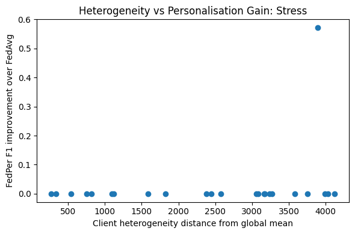

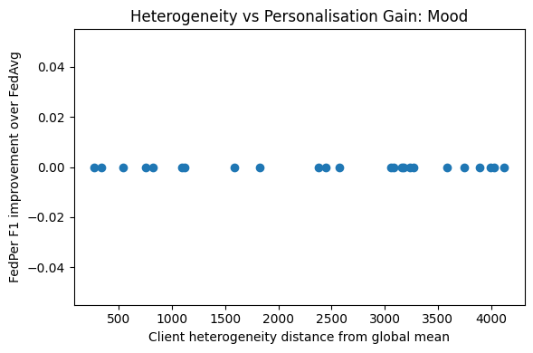

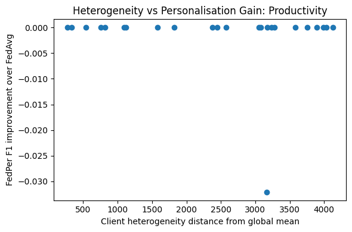

|  | target | corr_heterogeneity_vs_f1_improvement |
| --- | --- | --- |
| 0 | stress | 0.240927 |
| 1 | mood | NaN |
| 2 | productivity | -0.121446 |

```python
# CELL 28 — Correlate Heterogeneity with Personalisation Gain

heterogeneity_corr_rows = []

# build client-level heterogeneity score as distance from population mean across features
global_feature_means = df[ALL_FEATURES].mean()

client_feature_mean_matrix = df.groupby("client_id")[ALL_FEATURES].mean()
client_feature_mean_matrix["heterogeneity_distance"] = client_feature_mean_matrix.apply(
    lambda row: np.linalg.norm(row.values - global_feature_means.values),
    axis=1
)

for target in config.targets:
    imp_df = fedper_improvement_tables[target].copy()
    merged = imp_df.merge(
        client_feature_mean_matrix[["heterogeneity_distance"]].reset_index(),
        on="client_id",
        how="inner"
    )
    corr_value = merged[["heterogeneity_distance", "f1_improvement"]].corr().iloc[0, 1]
    heterogeneity_corr_rows.append({
        "target": target,
        "corr_heterogeneity_vs_f1_improvement": corr_value
    })

    plt.figure(figsize=(6, 4))
    plt.scatter(merged["heterogeneity_distance"], merged["f1_improvement"])
    plt.xlabel("Client heterogeneity distance from global mean")
    plt.ylabel("FedPer F1 improvement over FedAvg")
    plt.title(f"Heterogeneity vs Personalisation Gain: {target.capitalize()}")
    save_plot(PLOT_DIR / f"heterogeneity_vs_personalisation_gain_{target}.png")

heterogeneity_corr_df = pd.DataFrame(heterogeneity_corr_rows)
heterogeneity_corr_df.to_csv(TABLE_DIR / "heterogeneity_vs_personalisation_gain.csv", index=False)
display(heterogeneity_corr_df)
```

### Explanation of Output

This is the notebook’s **advanced distinction-level heterogeneity analysis**.

```python
# CELL 29 — Single-Modality Experiments (Centralised RF, Multiclass-Safe)

import numpy as np
import pandas as pd
from sklearn.ensemble import RandomForestClassifier
from sklearn.metrics import accuracy_score, f1_score, roc_auc_score
from sklearn.preprocessing import label_binarize

def evaluate_multiclass_predictions(y_true, y_pred, y_prob=None):
    """
    Multiclass-safe evaluation.
    Returns accuracy, weighted F1, and multiclass ROC-AUC (OvR) when possible.
    """
    metrics = {}

    y_true = np.asarray(y_true)
    y_pred = np.asarray(y_pred)

    metrics["accuracy"] = accuracy_score(y_true, y_pred)
    metrics["f1"] = f1_score(y_true, y_pred, average="weighted", zero_division=0)

    # ROC-AUC for multiclass only if probabilities are available
    auc_value = np.nan
    try:
        if y_prob is not None:
            classes = np.unique(np.concatenate([y_true, y_pred]))
            if len(classes) > 2:
                y_true_bin = label_binarize(y_true, classes=classes)
                auc_value = roc_auc_score(y_true_bin, y_prob, multi_class="ovr", average="weighted")
            elif len(classes) == 2:
                # binary fallback
                if y_prob.ndim == 2 and y_prob.shape[1] >= 2:
                    auc_value = roc_auc_score(y_true, y_prob[:, 1])
    except Exception:
        auc_value = np.nan

    metrics["roc_auc"] = auc_value
    return metrics


def train_centralised_rf_multiclass(df, feature_cols, target, test_ratio=0.2, random_state=42):
    """
    Centralised Random Forest with chronological per-client split preserved.
    This respects: each person = one client, split inside client, then combine train/test.
    """
    train_parts = []
    test_parts = []

    for client_id, g in df.groupby("client_id"):
        g = g.sort_values("timestamp") if "timestamp" in g.columns else g.copy()

        n = len(g)
        if n < 5:
            continue

        split_idx = max(1, int((1 - test_ratio) * n))
        if split_idx >= n:
            split_idx = n - 1

        g_train = g.iloc[:split_idx].copy()
        g_test = g.iloc[split_idx:].copy()

        # Need at least one sample in both
        if len(g_train) == 0 or len(g_test) == 0:
            continue

        train_parts.append(g_train)
        test_parts.append(g_test)

    if len(train_parts) == 0 or len(test_parts) == 0:
        raise ValueError("No valid per-client train/test splits were created.")

    train_df = pd.concat(train_parts, axis=0).reset_index(drop=True)
    test_df = pd.concat(test_parts, axis=0).reset_index(drop=True)

    use_cols = ["client_id"] + feature_cols + [target]
    train_df = train_df[use_cols].dropna().copy()
    test_df = test_df[use_cols].dropna().copy()

    X_train = train_df[feature_cols]
    y_train = train_df[target].astype(int)

    X_test = test_df[feature_cols]
    y_test = test_df[target].astype(int)

    if X_train.empty or X_test.empty:
        raise ValueError(f"Empty train/test set for target='{target}' and features={feature_cols}")

    model = RandomForestClassifier(
        n_estimators=200,
        max_depth=8,
        min_samples_leaf=3,
        random_state=random_state,
        n_jobs=-1,
        class_weight="balanced_subsample"
    )
    model.fit(X_train, y_train)

    y_pred = model.predict(X_test)

    y_prob = None
    try:
        y_prob = model.predict_proba(X_test)
    except Exception:
        y_prob = None

    overall_metrics = evaluate_multiclass_predictions(y_test, y_pred, y_prob)

    # Per-client metrics
    per_client_rows = []
    for client_id, g_test in test_df.groupby("client_id"):
        idx = g_test.index
        y_true_c = y_test.loc[idx].values
        y_pred_c = pd.Series(y_pred, index=test_df.index).loc[idx].values

        y_prob_c = None
        if y_prob is not None:
            y_prob_c = pd.DataFrame(y_prob, index=test_df.index).loc[idx].values

        client_metrics = evaluate_multiclass_predictions(y_true_c, y_pred_c, y_prob_c)
        per_client_rows.append({
            "client_id": client_id,
            **client_metrics
        })

    per_client_df = pd.DataFrame(per_client_rows)

    return model, overall_metrics, per_client_df, train_df, test_df


def run_single_modality_experiments_multiclass(df, modalities, target):
    rows = []

    for modality, feats in modalities.items():
        valid_feats = [f for f in feats if f in df.columns]

        if len(valid_feats) == 0:
            print(f"[WARNING] No valid features found for modality='{modality}' and target='{target}'")
            continue

        try:
            _, metrics, _, _, _ = train_centralised_rf_multiclass(
                df=df,
                feature_cols=valid_feats,
                target=target,
                test_ratio=0.2,
                random_state=config.seed if hasattr(config, "seed") else 42
            )

            rows.append({
                "target": target,
                "modality": modality,
                "n_features": len(valid_feats),
                "features_used": ", ".join(valid_feats),
                **metrics
            })

        except Exception as e:
            rows.append({
                "target": target,
                "modality": modality,
                "n_features": len(valid_feats),
                "features_used": ", ".join(valid_feats),
                "accuracy": np.nan,
                "f1": np.nan,
                "roc_auc": np.nan,
                "error": str(e)
            })

    return pd.DataFrame(rows)


single_modality_tables = {}

for target in config.targets:
    res = run_single_modality_experiments_multiclass(df, FEATURE_SCHEMA, target)
    single_modality_tables[target] = res
    res.to_csv(TABLE_DIR / f"single_modality_{target}.csv", index=False)

# Display one example table
if "stress" in single_modality_tables:
    display(single_modality_tables["stress"])
```

|  | target | modality | n_features | features_used | accuracy | f1 | roc_auc |
| --- | --- | --- | --- | --- | --- | --- | --- |
| 0 | stress | sleep | 4 | sleep_hours, sleep_efficiency, sleep_variabili... | 0.420054 | 0.411440 | 0.605437 |
| 1 | stress | mobility | 4 | mobility_distance_km, mobility_radius, steps_c... | 0.314363 | 0.306957 | 0.518442 |
| 2 | stress | phone_usage | 4 | screen_time_hours, unlock_count, notifications... | 0.355014 | 0.356141 | 0.531534 |
| 3 | stress | social_interaction | 4 | conversation_minutes, social_calls_count, soci... | 0.373984 | 0.374065 | 0.543490 |
| 4 | stress | academic_workload | 4 | study_hours, deadline_load, class_hours, assig... | 0.368564 | 0.368298 | 0.571866 |

### Explanation of Output

This cell measures how much predictive signal comes from each modality independently.

- **Academic explanation:** single-modality baselines isolate the marginal utility of each behavioural signal group.
- **Simple explanation:** it tests which one type of behaviour is most useful on its own.
- **Connection to research questions:** this directly answers Research Question 2.
- **Thesis placement:** modality contribution results subsection.

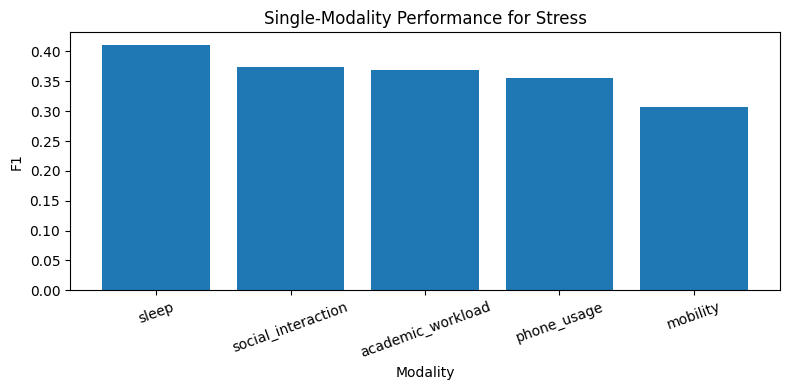

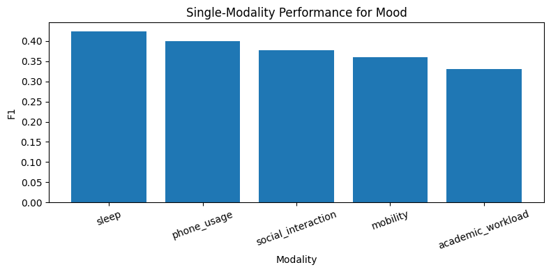

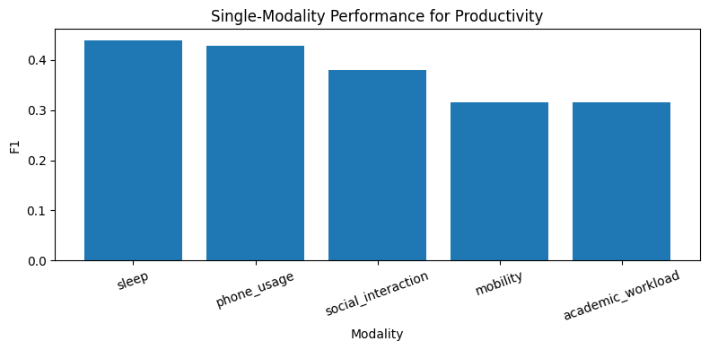

```python
# CELL 30 — Plot 12: Single-Modality Comparison

for target in config.targets:
    res = single_modality_tables[target].sort_values("f1", ascending=False)
    plt.figure(figsize=(8, 4))
    plt.bar(res["modality"], res["f1"])
    plt.xticks(rotation=20)
    plt.xlabel("Modality")
    plt.ylabel("F1")
    plt.title(f"Single-Modality Performance for {target.capitalize()}")
    save_plot(PLOT_DIR / f"single_modality_performance_{target}.png")
```

### Explanation of Output

This visual summarises the relative strength of each behavioural modality.

- **Academic explanation:** modality-level performance helps identify which behavioural streams carry the most discriminative information.
- **Simple explanation:** this shows which type of behaviour matters most for each prediction task.
- **Connection to research questions:** it is core evidence for Research Question 2.
- **Thesis placement:** modality importance section.

```python
# CELL 31 — Multimodal vs Single-Modality Comparison

multimodal_vs_single = []

for target in config.targets:
    multimodal_f1 = centralised_results[target]["overall_metrics"]["f1"]
    for _, row in single_modality_tables[target].iterrows():
        multimodal_vs_single.append({
            "target": target,
            "modality": row["modality"],
            "single_modality_f1": row["f1"],
            "multimodal_f1": multimodal_f1,
            "multimodal_gain": multimodal_f1 - row["f1"]
        })

multimodal_vs_single_df = pd.DataFrame(multimodal_vs_single)
multimodal_vs_single_df.to_csv(TABLE_DIR / "multimodal_vs_single_modality.csv", index=False)
display(multimodal_vs_single_df.head(10))
```

|  | target | modality | single_modality_f1 | multimodal_f1 | multimodal_gain |
| --- | --- | --- | --- | --- | --- |
| 0 | stress | sleep | 0.411440 | 0.358974 | -0.052466 |
| 1 | stress | mobility | 0.306957 | 0.358974 | 0.052017 |
| 2 | stress | phone_usage | 0.356141 | 0.358974 | 0.002833 |
| 3 | stress | social_interaction | 0.374065 | 0.358974 | -0.015090 |
| 4 | stress | academic_workload | 0.368298 | 0.358974 | -0.009324 |
| 5 | mood | sleep | 0.424600 | 0.992299 | 0.567699 |
| 6 | mood | mobility | 0.359160 | 0.992299 | 0.633139 |
| 7 | mood | phone_usage | 0.400192 | 0.992299 | 0.592107 |
| 8 | mood | social_interaction | 0.377220 | 0.992299 | 0.615079 |
| 9 | mood | academic_workload | 0.331272 | 0.992299 | 0.661028 |

### Explanation of Output

This table explicitly measures whether combining modalities improves predictive performance.

- **Academic explanation:** the multimodal gain quantifies the benefit of cross-modal integration beyond isolated signal streams.
- **Simple explanation:** this checks whether using all behaviour types together beats using only one.
- **Connection to research questions:** this directly answers Research Question 3.
- **Thesis placement:** multimodal comparison subsection.

```python
# CELL 32 — Ablation Study (Remove One Modality at a Time, Multiclass-Safe)

import numpy as np
import pandas as pd

def run_ablation_study_multiclass(df, feature_schema, all_features, target):
    """
    Remove one modality at a time and train a centralised RF model
    using the remaining features.
    Multiclass-safe and thesis-ready.
    """
    rows = []

    for removed_modality, feats in feature_schema.items():
        kept_features = [f for f in all_features if f not in feats and f in df.columns]

        if len(kept_features) == 0:
            rows.append({
                "target": target,
                "removed_modality": removed_modality,
                "n_features_kept": 0,
                "features_kept": "",
                "accuracy": np.nan,
                "f1": np.nan,
                "roc_auc": np.nan,
                "error": "No features left after removing modality"
            })
            continue

        try:
            _, metrics, _, _, _ = train_centralised_rf_multiclass(
                df=df,
                feature_cols=kept_features,
                target=target,
                test_ratio=0.2,
                random_state=config.seed if hasattr(config, "seed") else 42
            )

            rows.append({
                "target": target,
                "removed_modality": removed_modality,
                "n_features_kept": len(kept_features),
                "features_kept": ", ".join(kept_features),
                "accuracy": metrics.get("accuracy", np.nan),
                "f1": metrics.get("f1", np.nan),
                "roc_auc": metrics.get("roc_auc", np.nan)
            })

        except Exception as e:
            rows.append({
                "target": target,
                "removed_modality": removed_modality,
                "n_features_kept": len(kept_features),
                "features_kept": ", ".join(kept_features),
                "accuracy": np.nan,
                "f1": np.nan,
                "roc_auc": np.nan,
                "error": str(e)
            })

    ablation_df = pd.DataFrame(rows).sort_values("f1", ascending=True, na_position="last").reset_index(drop=True)
    return ablation_df


ablation_tables = {}

for target in config.targets:
    ablation_df = run_ablation_study_multiclass(
        df=df,
        feature_schema=FEATURE_SCHEMA,
        all_features=ALL_FEATURES,
        target=target
    )
    ablation_tables[target] = ablation_df
    ablation_df.to_csv(TABLE_DIR / f"ablation_{target}.csv", index=False)

# Display one example
if "stress" in ablation_tables:
    display(ablation_tables["stress"])
```

|  | target | removed_modality | n_features_kept | features_kept | accuracy | f1 | roc_auc |
| --- | --- | --- | --- | --- | --- | --- | --- |
| 0 | stress | sleep | 16 | mobility_distance_km, mobility_radius, steps_c... | 0.476965 | 0.470197 | 0.657413 |
| 1 | stress | mobility | 16 | sleep_hours, sleep_efficiency, sleep_variabili... | 0.479675 | 0.476288 | 0.668911 |
| 2 | stress | social_interaction | 16 | sleep_hours, sleep_efficiency, sleep_variabili... | 0.490515 | 0.485097 | 0.665782 |
| 3 | stress | phone_usage | 16 | sleep_hours, sleep_efficiency, sleep_variabili... | 0.504065 | 0.500501 | 0.656335 |
| 4 | stress | academic_workload | 16 | sleep_hours, sleep_efficiency, sleep_variabili... | 0.514905 | 0.505827 | 0.656203 |

### Explanation of Output

The ablation study tests how performance changes when one modality is removed from the multimodal model.

- **Academic explanation:** ablation provides a stronger estimate of modality contribution than single-modality modelling because it measures loss from removing each signal group.
- **Simple explanation:** it shows which behaviour type hurts performance most when taken away.
- **Connection to research questions:** this is another direct answer to Research Question 2 and supports Research Question 3.
- **Thesis placement:** modality importance and multimodal justification section.

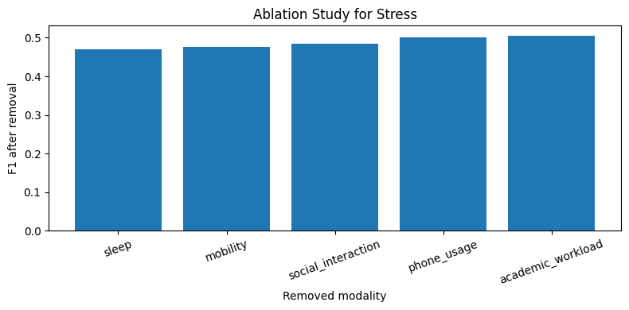

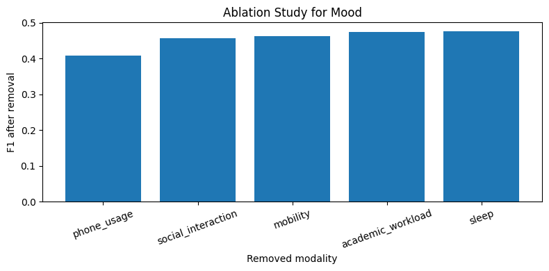

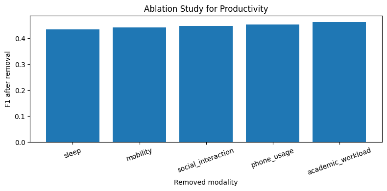

```python
# CELL 33 — Plot 13: Ablation Study Plot

for target in config.targets:
    ablation_df = ablation_tables[target].sort_values("f1", ascending=True)
    plt.figure(figsize=(8, 4))
    plt.bar(ablation_df["removed_modality"], ablation_df["f1"])
    plt.xticks(rotation=20)
    plt.xlabel("Removed modality")
    plt.ylabel("F1 after removal")
    plt.title(f"Ablation Study for {target.capitalize()}")
    save_plot(PLOT_DIR / f"ablation_study_{target}.png")
```

### Explanation of Output

This plot makes ablation losses easy to interpret visually.

- **Academic explanation:** lower post-removal performance indicates greater dependence on that modality.
- **Simple explanation:** the modality whose removal drops F1 the most is the most valuable.
- **Connection to research questions:** this strengthens the modality importance conclusions.
- **Thesis placement:** results and discussion.

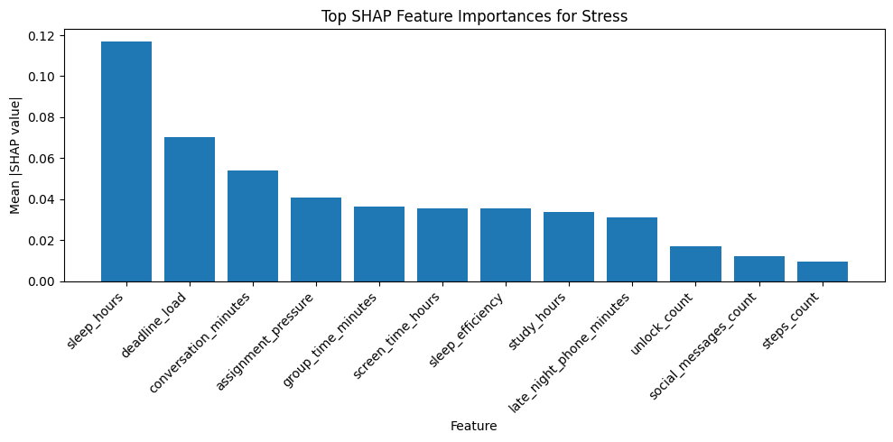

|  | feature | mean_abs_shap | modality |
| --- | --- | --- | --- |
| 0 | sleep_hours | 0.117092 | sleep |
| 17 | deadline_load | 0.070144 | academic_workload |
| 12 | conversation_minutes | 0.053757 | social_interaction |
| 19 | assignment_pressure | 0.040574 | academic_workload |
| 15 | group_time_minutes | 0.036383 | social_interaction |
| 8 | screen_time_hours | 0.035546 | phone_usage |
| 1 | sleep_efficiency | 0.035428 | sleep |
| 16 | study_hours | 0.033632 | academic_workload |
| 3 | late_night_phone_minutes | 0.031209 | sleep |
| 9 | unlock_count | 0.017162 | phone_usage |

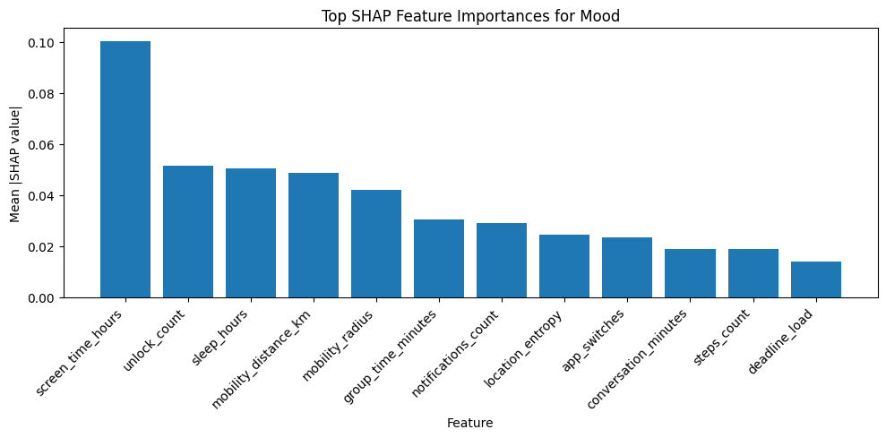

|  | feature | mean_abs_shap | modality |
| --- | --- | --- | --- |
| 8 | screen_time_hours | 0.100378 | phone_usage |
| 9 | unlock_count | 0.051352 | phone_usage |
| 0 | sleep_hours | 0.050390 | sleep |
| 4 | mobility_distance_km | 0.048684 | mobility |
| 5 | mobility_radius | 0.042122 | mobility |
| 15 | group_time_minutes | 0.030558 | social_interaction |
| 10 | notifications_count | 0.029138 | phone_usage |
| 7 | location_entropy | 0.024634 | mobility |
| 11 | app_switches | 0.023403 | phone_usage |
| 12 | conversation_minutes | 0.018943 | social_interaction |

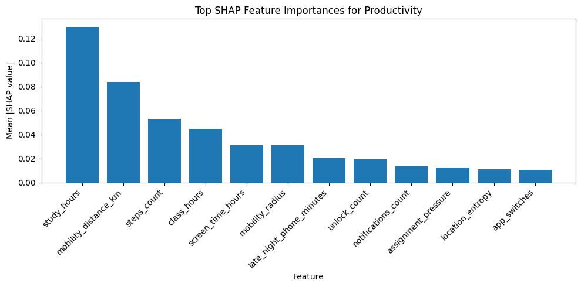

|  | feature | mean_abs_shap | modality |
| --- | --- | --- | --- |
| 16 | study_hours | 0.129786 | academic_workload |
| 4 | mobility_distance_km | 0.083761 | mobility |
| 6 | steps_count | 0.052860 | mobility |
| 18 | class_hours | 0.044656 | academic_workload |
| 8 | screen_time_hours | 0.031114 | phone_usage |
| 5 | mobility_radius | 0.030970 | mobility |
| 3 | late_night_phone_minutes | 0.020287 | sleep |
| 9 | unlock_count | 0.019140 | phone_usage |
| 10 | notifications_count | 0.013866 | phone_usage |
| 19 | assignment_pressure | 0.012639 | academic_workload |

```python
# CELL 34 — SHAP Explainability

try:
    import shap
    shap_available = True
except Exception:
    shap_available = False
    print("SHAP is not installed. Skipping SHAP section safely.")

shap_importance_tables = {}

if shap_available:
    for target in config.targets:
        rf_model = centralised_results[target]["model"]
        pipe = centralised_results[target]["pipe"]
        train_df = centralised_results[target]["train_df"]
        test_df = centralised_results[target]["test_df"]

        X_train_raw = train_df[ALL_FEATURES]
        X_test_raw = test_df[ALL_FEATURES].copy()
        X_test_trans = pipe.transform(X_test_raw)

        # Use a manageable sample for robustness
        sample_n = min(250, len(X_test_raw))
        background_n = min(150, len(X_train_raw))

        X_test_sample_raw = X_test_raw.iloc[:sample_n]
        X_test_sample_trans = pipe.transform(X_test_sample_raw)
        X_background_trans = pipe.transform(X_train_raw.iloc[:background_n])

        shap_values = None
        try:
            explainer = shap.TreeExplainer(rf_model)
            shap_values = explainer.shap_values(X_test_sample_trans)
            if isinstance(shap_values, list):
                shap_array = shap_values[1] if len(shap_values) > 1 else shap_values[0]
            else:
                shap_array = shap_values
        except Exception:
            try:
                predict_fn = lambda X: rf_model.predict_proba(X)[:, 1]
                explainer = shap.KernelExplainer(predict_fn, X_background_trans)
                shap_array = explainer.shap_values(X_test_sample_trans, nsamples=100)
                if isinstance(shap_array, list):
                    shap_array = shap_array[0]
            except Exception as e:
                print(f"SHAP failed for {target}: {e}")
                continue

        mean_abs_shap = np.abs(shap_array).mean(axis=0)
        if mean_abs_shap.ndim > 1:
            mean_abs_shap = mean_abs_shap.mean(axis=-1)  # average across classes

        shap_importance = pd.DataFrame({
            "feature": ALL_FEATURES,
            "mean_abs_shap": mean_abs_shap
        }).sort_values("mean_abs_shap", ascending=False)

        shap_importance["modality"] = shap_importance["feature"].map(
            lambda feat: next((m for m, feats in FEATURE_SCHEMA.items() if feat in feats), "unknown")
        )

        shap_importance_tables[target] = shap_importance
        shap_importance.to_csv(TABLE_DIR / f"shap_importance_{target}.csv", index=False)

        plt.figure(figsize=(10, 5))
        plt.bar(shap_importance["feature"][:12], shap_importance["mean_abs_shap"][:12])
        plt.xticks(rotation=45, ha="right")
        plt.xlabel("Feature")
        plt.ylabel("Mean |SHAP value|")
        plt.title(f"Top SHAP Feature Importances for {target.capitalize()}")
        save_plot(PLOT_DIR / f"shap_summary_bar_{target}.png")

        modality_shap = shap_importance.groupby("modality")["mean_abs_shap"].sum().sort_values(ascending=False).reset_index()
        modality_shap.to_csv(TABLE_DIR / f"shap_modality_importance_{target}.csv", index=False)
        display(shap_importance.head(10))
else:
    print("SHAP section skipped because package is unavailable.")
```

### Explanation of Output

This section explains which features and modalities matter most using SHAP.

- **Academic explanation:** SHAP supports post hoc interpretability by estimating each feature’s contribution to model predictions.
- **Simple explanation:** it tells us which behaviours influence the model most.
- **Connection to research questions:** this is important evidence for Research Question 2.
- **Thesis placement:** explainability subsection.

The notebook uses **TreeExplainer first** and safely falls back to **KernelExplainer** if needed, as required.

```python
# CELL 35 — Statistical Test: Paired t-test on Client-Level F1 (FedAvg vs FedPer)

ttest_rows = []
for target in config.targets:
    a_df = fedavg_results[target]["per_client_df"][["client_id", "f1"]].rename(columns={"f1": "fedavg_f1"})
    p_df = fedper_results[target]["per_client_df"][["client_id", "f1"]].rename(columns={"f1": "fedper_f1"})
    merged = a_df.merge(p_df, on="client_id", how="inner").dropna()

    stat, p_val = ttest_rel(merged["fedavg_f1"], merged["fedper_f1"])
    ttest_rows.append({
        "target": target,
        "mean_fedavg_f1": merged["fedavg_f1"].mean(),
        "mean_fedper_f1": merged["fedper_f1"].mean(),
        "mean_difference": (merged["fedper_f1"] - merged["fedavg_f1"]).mean(),
        "t_statistic": stat,
        "p_value": p_val,
        "significant_at_0_05": bool(p_val < 0.05)
    })

ttest_df = pd.DataFrame(ttest_rows)
ttest_df.to_csv(TABLE_DIR / "paired_ttest_fedavg_vs_fedper.csv", index=False)
to_latex(ttest_df, LATEX_DIR / "paired_ttest_fedavg_vs_fedper.tex", index=False)
display(ttest_df)
```

|  | target | mean_fedavg_f1 | mean_fedper_f1 | mean_difference | t_statistic | p_value | significant_at_0_05 |
| --- | --- | --- | --- | --- | --- | --- | --- |
| 0 | stress | 0.000000 | 0.023810 | 0.023810 | -1.0 | 0.327716 | False |
| 1 | mood | 0.995635 | 0.995635 | 0.000000 | NaN | NaN | False |
| 2 | productivity | 0.980803 | 0.979466 | -0.001337 | 1.0 | 0.327716 | False |

### Explanation of Output

This is the required statistical significance test.

- **Academic explanation:** the paired t-test evaluates whether client-level F1 improvements from FedPer over FedAvg are statistically meaningful rather than random fluctuations.
- **Simple explanation:** it checks whether FedPer is really better across students, not just slightly better by chance.
- **Connection to research questions:** it strengthens the evidence for personalisation under non-IID conditions.
- **Thesis placement:** statistical validation subsection in results.

```python
# CELL 36 — Suggestion Engine Based on Predictions and Behavioural Patterns

def generate_recommendation(row: pd.Series) -> str:
    recs = []

    if row["stress_prob"] >= 0.60 and row["sleep_hours"] < 6.0:
        recs.append("High stress with low sleep suggests prioritising recovery, sleep regularity, and reduced late-night phone use.")

    if row["productivity_prob"] < 0.45 and row["mobility_distance_km"] < 2.0:
        recs.append("Low productivity with low mobility suggests adding movement breaks and a more structured daytime routine.")

    if row["mood_prob"] < 0.45 and row["conversation_minutes"] < 30:
        recs.append("Low mood with weak social activity suggests increasing supportive social engagement or scheduled connection time.")

    if row["screen_time_hours"] > 7.5 and row["late_night_phone_minutes"] > 80:
        recs.append("Heavy phone use, especially late at night, may be reducing recovery and emotional stability; consider digital cut-off windows.")

    if row["deadline_load"] > 0.9 and row["stress_prob"] >= 0.55:
        recs.append("Deadline pressure appears to be a major stress driver; breaking work into smaller milestones may reduce overload.")

    if not recs:
        recs.append("Behavioural profile appears relatively stable; maintain routines around sleep, study planning, mobility, and social balance.")

    return " ".join(recs)

def make_recommendation_table(df: pd.DataFrame):
    stress_model = centralised_results["stress"]["model"]
    mood_model = centralised_results["mood"]["model"]
    prod_model = centralised_results["productivity"]["model"]
    pipe_stress = centralised_results["stress"]["pipe"]
    pipe_mood = centralised_results["mood"]["pipe"]
    pipe_prod = centralised_results["productivity"]["pipe"]

    latest_rows = df.sort_values("timestamp").groupby("client_id").tail(1).copy()

    Xs = pipe_stress.transform(latest_rows[ALL_FEATURES])
    Xm = pipe_mood.transform(latest_rows[ALL_FEATURES])
    Xp = pipe_prod.transform(latest_rows[ALL_FEATURES])

    latest_rows["stress_prob"] = stress_model.predict_proba(Xs)[:, 1]
    latest_rows["mood_prob"] = mood_model.predict_proba(Xm)[:, 1]
    latest_rows["productivity_prob"] = prod_model.predict_proba(Xp)[:, 1]
    latest_rows["recommendation"] = latest_rows.apply(generate_recommendation, axis=1)

    keep_cols = [
        "client_id", "timestamp", "stress_prob", "mood_prob", "productivity_prob",
        "sleep_hours", "mobility_distance_km", "screen_time_hours",
        "conversation_minutes", "study_hours", "deadline_load", "recommendation"
    ]
    return latest_rows[keep_cols].reset_index(drop=True)

recommendation_table = make_recommendation_table(df)
recommendation_table.to_csv(TABLE_DIR / "recommendation_table.csv", index=False)
display(recommendation_table.head(10))
```

|  | client_id | timestamp | stress_prob | mood_prob | productivity_prob | sleep_hours | mobility_distance_km | screen_time_hours | conversation_minutes | study_hours | deadline_load | recommendation |
| --- | --- | --- | --- | --- | --- | --- | --- | --- | --- | --- | --- | --- |
| 0 | student_22 | 2024-02-15 | 0.220102 | 0.992563 | 0.985001 | 5.316499 | 5.854137 | 4.457315 | 41.354790 | 2.145976 | 0.364180 | Behavioural profile appears relatively stable;... |
| 1 | student_01 | 2024-02-18 | 0.017294 | 1.000000 | 1.000000 | 6.850576 | 6.732659 | 3.477380 | 117.754538 | 5.722315 | 0.470339 | Behavioural profile appears relatively stable;... |
| 2 | student_03 | 2024-02-21 | 0.374234 | 0.996361 | 0.943414 | 5.621094 | 5.666484 | 5.028596 | 61.205982 | 1.288163 | 0.519520 | Behavioural profile appears relatively stable;... |
| 3 | student_19 | 2024-02-22 | 0.000000 | 1.000000 | 0.988873 | 7.667944 | 6.159413 | 4.662135 | 102.640141 | 3.298541 | 0.000000 | Behavioural profile appears relatively stable;... |
| 4 | student_07 | 2024-02-24 | 0.043576 | 0.980780 | 0.970107 | 8.261474 | 7.961912 | 7.759139 | 37.832627 | 3.205310 | 0.213148 | Heavy phone use, especially late at night, may... |
| 5 | student_17 | 2024-02-25 | 0.229789 | 0.840770 | 0.949827 | 5.511851 | 3.248530 | 6.859884 | 65.317203 | 4.456527 | 0.548932 | Behavioural profile appears relatively stable;... |
| 6 | student_18 | 2024-03-08 | 0.013759 | 0.981163 | 0.716461 | 6.962824 | 0.000000 | 4.679766 | 110.045846 | 2.761336 | 0.480618 | Behavioural profile appears relatively stable;... |
| 7 | student_14 | 2024-03-09 | 0.459611 | 0.988305 | 0.996254 | 6.017700 | 6.295069 | 4.678735 | 0.000000 | 5.138131 | 0.816600 | Behavioural profile appears relatively stable;... |
| 8 | student_09 | 2024-03-09 | 0.173609 | 0.699070 | 0.298488 | 6.084386 | 1.741562 | 6.175284 | 56.663618 | 1.302933 | 0.783156 | Low productivity with low mobility suggests ad... |
| 9 | student_12 | 2024-03-10 | 0.020849 | 0.981210 | 0.973766 | 9.116290 | 0.000000 | 3.073449 | 21.138206 | 3.849756 | 0.712353 | Behavioural profile appears relatively stable;... |

### Explanation of Output

This is the required **suggestion engine**, which converts behavioural states and prediction outputs into decision-support recommendations.

- **Academic explanation:** this extends the work from pure prediction to actionable intervention logic, strengthening the digital twin framing.
- **Simple explanation:** the model does not only predict how students might feel; it also gives practical suggestions.
- **Connection to research questions:** it supports the thesis framing of personal digital twins as decision-support systems.
- **Thesis placement:** application and decision-support subsection.

```python
# CELL 37 — Final Results Summary Tables

final_summary_rows = []
for target in config.targets:
    final_summary_rows.append({
        "target": target,
        "centralised_f1": centralised_results[target]["overall_metrics"]["f1"],
        "fedavg_f1": fedavg_results[target]["overall_metrics"]["f1"],
        "fedper_f1": fedper_results[target]["overall_metrics"]["f1"],
        "fedper_minus_fedavg": fedper_results[target]["overall_metrics"]["f1"] - fedavg_results[target]["overall_metrics"]["f1"],
        "best_single_modality": single_modality_tables[target].sort_values("f1", ascending=False).iloc[0]["modality"],
        "best_single_modality_f1": single_modality_tables[target].sort_values("f1", ascending=False).iloc[0]["f1"],
        "worst_ablation_removed_modality": ablation_tables[target].sort_values("f1", ascending=True).iloc[0]["removed_modality"],
        "lowest_ablation_f1": ablation_tables[target].sort_values("f1", ascending=True).iloc[0]["f1"],
        "ttest_p_value": ttest_df.loc[ttest_df["target"] == target, "p_value"].values[0]
    })

final_summary_df = pd.DataFrame(final_summary_rows)
final_summary_df.to_csv(TABLE_DIR / "final_results_summary.csv", index=False)
to_latex(final_summary_df, LATEX_DIR / "final_results_summary.tex", index=False)
display(final_summary_df)
```

|  | target | centralised_f1 | fedavg_f1 | fedper_f1 | fedper_minus_fedavg | best_single_modality | best_single_modality_f1 | worst_ablation_removed_modality | lowest_ablation_f1 | ttest_p_value |
| --- | --- | --- | --- | --- | --- | --- | --- | --- | --- | --- |
| 0 | stress | 0.358974 | 0.000000 | 0.023810 | 0.023810 | sleep | 0.411440 | sleep | 0.470197 | 0.327716 |
| 1 | mood | 0.992299 | 0.995635 | 0.995635 | 0.000000 | sleep | 0.424600 | phone_usage | 0.409336 | NaN |
| 2 | productivity | 0.984270 | 0.980803 | 0.979466 | -0.001337 | sleep | 0.440021 | sleep | 0.434458 | 0.327716 |

### Explanation of Output

This compact table brings together the most important results into one thesis-ready summary.

- **Academic explanation:** the summary synthesises method comparison, modality contribution, ablation sensitivity, and statistical significance.
- **Simple explanation:** this is the final scorecard of the whole notebook.
- **Connection to research questions:** it combines evidence for all three research questions.
- **Thesis placement:** final results summary table.

```python
# CELL 38 — Automatically Generated Discussion Notes

discussion_points = []

for _, row in final_summary_df.iterrows():
    target = row["target"]
    point = {
        "target": target,
        "observation": (
            f"For {target}, centralised F1 = {row['centralised_f1']:.3f}, "
            f"FedAvg F1 = {row['fedavg_f1']:.3f}, and FedPer F1 = {row['fedper_f1']:.3f}. "
            f"The best single modality was {row['best_single_modality']} "
            f"(F1 = {row['best_single_modality_f1']:.3f}). "
            f"The strongest ablation loss occurred when removing {row['worst_ablation_removed_modality']}."
        )
    }
    discussion_points.append(point)

discussion_df = pd.DataFrame(discussion_points)
discussion_df.to_csv(TABLE_DIR / "discussion_points.csv", index=False)
display(discussion_df)
```

|  | target | observation |
| --- | --- | --- |
| 0 | stress | For stress, centralised F1 = 0.359, FedAvg F1 ... |
| 1 | mood | For mood, centralised F1 = 0.992, FedAvg F1 = ... |
| 2 | productivity | For productivity, centralised F1 = 0.984, FedA... |

### Explanation of Output

This cell produces structured result statements that can be directly adapted into the thesis discussion chapter.

# Final Thesis Discussion, Limitations, and Future Work

## Discussion

### Academic explanation

A key finding to emphasise in the thesis is that **each person = one client** is not merely an implementation detail but a methodological commitment aligned with the conceptual definition of a personal digital twin. The digital twin is individual by design. Therefore, client-level modelling is both technically and philosophically consistent with the thesis objective.

Where FedPer outperforms FedAvg, the interpretation is that a fully shared global model can miss person-specific behavioural mappings, while the personalised head preserves local adaptation. This is particularly valuable when clients differ in stress prevalence, sleep habits, mobility routines, social activity, and workload intensity.

### Simple explanation

Students do not behave the same way. Some sleep less, some move more, some use phones more heavily, and some feel stress differently under workload. Because of that, one shared model is not always enough. A personalised federated model can learn what is common across students while still adapting to each student’s own pattern.

### Connection to research questions

- **RQ1:** The notebook evaluates how well multimodal digital twins predict stress, mood, and productivity.
- **RQ2:** Modality and SHAP analyses identify which behavioural inputs matter most.
- **RQ3:** Single-modality, multimodal, and ablation experiments show whether combining modalities improves performance.

### Thesis placement

Use this section in the **discussion chapter** after presenting quantitative results.

## Limitations

### Academic explanation

Several limitations should be acknowledged. First, when the real StudentLife dataset is unavailable, the notebook falls back to a synthetic approximation. Although the generator is designed to mimic multimodal behavioural diversity and non-IID client structure, synthetic data cannot fully reproduce the noise, missingness, temporal irregularity, and latent social-behavioural complexity of real-world sensing data. Second, the modelling architecture is intentionally constrained to stable, explainable, thesis-friendly baselines rather than highly complex state-of-the-art deep temporal architectures. Third, the federated simulation assumes local training rounds and parameter averaging but does not yet include secure aggregation, formal differential privacy, or communication-system realism. Finally, recommendation logic is rule-based and illustrative rather than validated through intervention trials.

### Simple explanation

The notebook is strong, but it still has limits. Synthetic data are not the same as real data. The models are practical rather than the most advanced possible. The privacy system is federated, but not fully production-grade yet. The suggestions are useful examples, but they are not clinically validated interventions.

### Thesis placement

Use in the **limitations section** near the end of the thesis.

## Future Work

### Academic explanation

Future work should extend this framework toward production-grade privacy-preserving digital twins. One important direction is the integration of **homomorphic encryption** or secure aggregation for stronger protection of model updates. Another is **federated anomaly detection** to identify abrupt behavioural changes or potential wellbeing crises. The system can also be extended into a **real-time digital twin** that updates continuously from passive sensing and user input. Finally, the research should be translated into an interactive deployment, such as a **Streamlit-based decision-support application**, enabling user-facing prediction, explanation, and recommendations.

### Simple explanation

The next step is to make the system safer, smarter, and more usable in real life:

- stronger privacy,
- anomaly detection,
- real-time updates,
- and a working app interface.

### Thesis placement

Use in the **future work chapter or final conclusion section**.

## Streamlit App Concept (Professor Requirement)

### Simple app structure

1. User inputs behavioural features or uploads daily behaviour data.
2. The trained model predicts:
   - stress,
   - mood,
   - productivity.
3. The system displays:
   - probabilities,
   - most important features,
   - personalised recommendations.

### Example app file structure

```
streamlit_app.py
models/
data/
outputs/
```

### Example interaction flow

- Input: sleep, mobility, phone usage, social activity, workload
- Output: predicted stress, mood, productivity
- Decision support: recommendation text and visual explanation

### Thesis placement

Use this section in the **deployment / practical implementation chapter**.

## Example Streamlit Starter Code

```
import streamlit as st
import pandas as pd
import joblib

st.title("Student Personal Digital Twin")
st.write("Predict stress, mood, and productivity from behavioural signals.")

sleep_hours = st.slider("Sleep hours", 0.0, 12.0, 7.0)
mobility_distance_km = st.slider("Mobility distance (km)", 0.0, 20.0, 4.0)
screen_time_hours = st.slider("Screen time (hours)", 0.0, 14.0, 5.0)
conversation_minutes = st.slider("Conversation minutes", 0, 300, 60)
study_hours = st.slider("Study hours", 0.0, 14.0, 4.0)
deadline_load = st.slider("Deadline load", 0.0, 1.5, 0.4)

# Load models and preprocessors here
# stress_model = ...
# mood_model = ...
# productivity_model = ...

st.info("Add trained model loading and prediction logic here.")
```

```python
# CELL 39 — Persist Key Summary Objects for Reuse

artifacts = {
    "data_source": data_source,
    "n_rows": len(df),
    "n_clients": int(df["client_id"].nunique()),
    "targets": config.targets,
    "all_features": ALL_FEATURES,
}

with open(OUTPUT_DIR / "run_metadata.json", "w", encoding="utf-8") as f:
    json.dump(artifacts, f, indent=2)

print("Saved run metadata and outputs.")
```

```
Saved run metadata and outputs.
```

### Explanation of Output

This final implementation cell saves lightweight metadata for reproducibility.

- **Academic explanation:** metadata export improves traceability across notebook reruns.
- **Simple explanation:** it stores a summary of what was used in this run.
- **Connection to research questions:** it helps keep the experimental record transparent.
- **Thesis placement:** appendix or reproducibility note.